# The natural numbers

2020-06-02 23:02:09

# 1 The natural numbers

This section is based on (Mendelson 2008, Chapter 2, pp 53-85)

- We define the natural numbers as the positive integers, $\mathbb{P} = \{1, 2, 3, \ldots \}$
- In this part we present an axiomatic development of the natural numbers

## 1.1 Peano systems

By a **peano system** we mean

- A set $P$
- A particular element $1 \in P$
- A singularity operation $S$ on $P$ $(S: P \longrightarrow P) \land \mathscr{D}(S) = P$

Such that the following axioms are satisfied:

- $(P1) \; 1$ is not the *successor* $S(x)$ of any object $x \in P$:
  - $(\forall x)(x \in P \implies S(x) \neq 1)$
    - In that sense $1 \notin \mathscr{R}(S)$ so $\mathscr{R}(S) \subsetneq P$
- $(P2)$ Different objects in $P$ have different successors:
  - $(\forall x)(\forall y)((x \in P \land y \in P \land x \neq y) \implies S(x) \neq S(y))$
    - $S$ is one-one $(S: P \xrightarrow[]{\text{1-1}} P)$
- $(P3)$ *Principle of Mathematical Induction*: Any subset of $P$ containing $1$ and closed under the successor operation must be identical with $P$
  - $(\forall B)((B \subseteq P \land 1 \in B \land (\forall x)(x \in B \implies S(x) \in P)) \implies B = P)$

Such a peano system will be denoted by the ordered triple $(P, S, 1)$

- $P$ is called the **underlying set**
- $S$ the **successor operation**
- $1$ the **distinguished element**
  - The distinguished element $1$ need not to have anything to do with the ordinary integer 1

### 1.1.1 Example of peano systems

- Let $P = \mathbb{P}$, $1$ the ordinary integer $1$ and $S$ equal to $S(x) = x + 1$ for all $x \in \mathbb{P}$
  - $S(x) = x + 1 \neq 1$
  - If $x \neq y$ then $x + 1 \neq y + 1$ so $S(x) \neq S(y)$
  - Let $B \subseteq \mathbb{P}$, $1 \in B$ and assume that if $x \in B$ then $x + 1 \in B$
    - If $1 \in B$ then $1 + 1 = 2 \in B$, $2 + 1 = 3 \in B$ and so on, where any $n \in \mathbb{P}$ can be reach
- Let $P = \mathbb{N}$ where $\mathbb{N} = \mathbb{P} \cup \{ 0 \}$, $1$ the ordinary integer $0$ and $S$ equal to $S(x) = x + 1$ for all $x \in \mathbb{N}$
  - $S(x) = x + 1 \neq 0$
  - If $x \neq y$ then $x + 1 \neq y + 1$ so $S(x) \neq S(y)$
  - Let $B \subseteq \mathbb{N}$, $0 \in B$ and assume that if $x \in B$ then $x + 1 \in B$
    - If $0 \in B$ then $0 + 1 = 1 \in B$, $1 + 1 = 2 \in B$ and so on, where any $n \in \mathbb{N}$ can be reach
- Let $P = \{ z: z \geq 1000 \land z \in \mathbb{Z} \}$, $1$ the ordinary integer $1000$ and $S$ equal to $S(x) = x + 1$ for all $x \in \{ z: z \geq 1000 \land z \in \mathbb{Z} \}$
  - $S(x) = x + 1 \neq 1000$
  - If $x \neq y$ then $x + 1 \neq y + 1$ so $S(x) \neq S(y)$
  - Let $B \subseteq \{ z: z \geq 1000 \land z \in \mathbb{Z} \}$, $1000 \in B$ and assume that if $x \in B$ then $x + 1 \in B$
    - If $1000 \in B$ then $1000 + 1 = 1001 \in B$, $1001 + 1 = 1002 \in B$ and so on, where any $x \in \{ z: z \geq 1000 \land z \in \mathbb{Z} \}$ can be reach
- Let $P = \mathbb{Z}^-$, $1$ the ordinary integer $-1$ and $S$ equal to $S(x) = x - 1$ for all $x \in \mathbb{Z}^-$
  - $S(x) = x - 1 \neq -1$
  - If $x \neq y$ then $x - 1 \neq y - 1$ so $S(x) \neq S(y)$
  - Let $B \subseteq \mathbb{Z}^-$, $-1 \in B$ and assume that if $x \in B$ then $x - 1 \in B$
    - If $-1 \in B$ then $-1 - 1 = -2 \in B$, $-2 -1 = -3 \in B$ and so on, where any $z \in \mathbb{Z}^-$ can be reach
- Let $P = \{z: z = 2n \land n \in \mathbb{P} \}$, $1$ the ordinary integer $2$ and $S$ equal to $S(x) = x + 2$ for all $x \in \{z: z = 2n \land n \in \mathbb{P} \}$
  - $S(x) = x + 2 \neq 2$
  - If $x \neq y$ then $x + 2 \neq y + 2$ so $S(x) \neq S(y)$
  - Let $B \subseteq \{z: z = 2n \land n \in \mathbb{P} \}$, $2 \in B$ and assume that if $x \in B$ then $x + 2 \in B$
    - If $2 \in B$ then $2 + 2 = 4 \in B$, $4 + 2 = 6 \in B$ and so on, where any $x \in \{z: z = 2n \land n \in \mathbb{P} \}$ can be reach

**Theorem** Every element different from $1$ and belonging to $P$ is a successor
$$(\forall x)((x \in P \land x \neq 1) \implies (\exists y)(y \in P \land x = S(y)))$$

Let $B = \{x: x = 1 \lor (\exists y)(x = S(y)) \}$

- $1 \in B$
- If $x \in B$ then $x = 1 \lor x = S(y)$ where $S(y) \neq 1 \land S(y) \in P$
  - Because $1 \in P \land S(y) \in P$ then $B \subseteq P$
- $\begin{split} x \in B \land x \neq 1 & \implies x = S(y) \\ & \implies S(x) = S(S(y)) \\ & \implies S(x) \in B \end{split}$
  - Therefore by the principle of mathematical induction $B = P$

**Theorem** No object is its own successor, that is, $(\forall x)(x \in P \land S(x) \neq x)$

Let $B = \{x: x \in P \land S(x) \neq x \}$

- $1 \in B$ because $1 \in P \land S(x) \neq 1$
- If $x \in B$ then $x \in P$ so $B \subseteq P$
- $\begin{split} x \in B \land & \implies S(x) \neq x \land S(x) \in P \land x \in P \\ & \implies S(S(x)) \neq S(x) \land S(x) \in P \\ & \implies S(x) \in B \end{split}$
  - Therefore by the principle of mathematical induction $B = P$

## 1.2 Peano systems exercises and solutions

1. Prove that every object different from $1$ is the successor of a unique object, that is,
   $$(\forall x)(x \in P \implies (x = 1 \lor (\exists !y)(y \in P \land x = S(y))))$$
- If $1 \in P$ then $1 = 1$
- If $x \in P \land x \neq 1$ then $(\exists y)(y \in P \land x = S(y))))$
  - Assume that there is another $z$ such that $z \in P \land x = S(z)$
    - Therefore $S(y) = S(z) \implies y = z$ because $S$ is a one-one function
      - Thus if $x \in P \land x \neq 1$ then $(\exists !y)(y \in P \land x = S(y))))$
2. Prove $(\forall x)(x \in P \implies (x = 1 \lor x = S(1) \lor x = S(S(y))))$
- If $1 \in P$ then $1 = 1$
- If $x \in P \land x \neq y$ then $(\exists !z)(z \in P \land x = S(z))$
  - If $z = 1$ then $x = S(1)$
  - If $z \neq 1$ then $(\exists !y)(y \in P \land z = S(y))$. Therefore $(\exists !y)(y \in P \land x = S(S(y)))$
3. Determine whether or not the following structures $(P, S, 1)$ are peano systems
   - $P$ is the set of all integers greater than $9$, $1$ stands for the integer $10$ and $S(u) = u + 1$ for any $u \in P$
     - $P = \{u: u \in \mathbb{Z} \land x > 9 \}$
       - $(\forall u)(u \in P \implies u + 1 \neq 10)$
       - $(\forall u)(\forall v)((u \in P \land v \in P \land u \neq v) \implies u + 1 \neq v + 1)$
       - Assume that $B \subseteq P$, $10 \in B$ and $(\forall u)(u \in B \implies u + 1 \in B)$
         - $10 \in P$, $10 + 1 = 11 \in P$, $11 + 1 = 12 \in P$ and so on where any $u \in P$ can be reach
   - $P$ is the set of all integers, $1$ stands for the ordinary integer $1$ and $S(u) = u + 1$ for all $u$ in $P$
     - $P = \mathbb{Z}$
       - $0 \in \mathbb{Z} \land S(0) = 0 + 1 = 1$. Therefore $S(0) = 1$
   - $P$ is the set of all integers, $1$ stands for the ordinary integer $0$ and
     $$S(u) = \begin{cases}
     1 & \text{if } u = 0 \\
     -u & \text{if } u > 0 \\
     -(u - 1) & \text{if } u < 0
     \end{cases}$$
     - $P = \mathbb{Z}$
       - $S(u) = 1 \lor S(u) < 0 \lor S(u) > 0$ so $S(x) \neq 0$
       - Let $u \in P \land v \in P \land u \neq v$
         - If $u = 0$ then $S(1) = 0 \land (v > 0 \lor v < 0)$
           - If $v > 0$ then $S(v) = -v < 0$ so $S(v) \neq S(u)$
           - If $v < 0$ then $S(v) = -(v-1) > 1$ so $S(v) \neq S(u)$
         - If $u > 0$ then $S(u) = -u < 0 \land (v = 0 \lor v < 0)$
           - If $v = 0$ then $S(v) = 1$ so $S(v) \neq S(u)$
           - If $v < 0$ then $S(v) = -(v-1) > 1$ so $S(v) \neq S(u)$
         - If $u < 0$ then $S(u) = -(u - 1) > 1 \land (v = 0 \lor v > 0)$
           - If $v = 0$ then $S(v) = 1$ so $S(v) \neq S(u)$
           - If $v < 0$ then $S(v) = -(v-1) > 1$ so $S(v) \neq S(u)$
       - Assume that $B \subseteq P$, $0 \in B$ and $(\forall u)(u \in B \implies S(u) \in B)$ where
         $$S(u) = \begin{cases}
         1 & \text{if } u = 0 \\
         -u & \text{if } u > 0 \\
         -(u - 1) & \text{if } u < 0
         \end{cases}$$
         - $0 \in B$, $S(0) = 1 > 0 \land 1 \in P$, $S(1) = -1 < 0 \land -1 \in P$, $S(-1) = -(-1 - 1) = 2 > 0 \land 2 \in P$, $S(2) = -2 < 0 \land -2 \in P$ and so on where any $u \in P$ can be reach
   - $P$ is the set of all rational numbers of the form $\frac{1}{2^n}$ where $n$ is a nonnegative integer, $1$ stands for the integer $1$ and $S(u) = \frac{1}{2}u$ for all $u \in P$
     - $P = \{u: u = \frac{1}{2^n} \land n \in \mathbb{Z^+}\}$
       - $1 \in P$ because $0 \in \mathbb{Z^+}$ and $\frac{1}{2^0} = \frac{1}{1} = 1$
       - $S(u) = \frac{1}{2}u$ where $u = \frac{1}{2^n}$ and $n \in \mathbb{Z^+}$. Therefore $S(u) = \frac{1}{2} \frac{1}{2^n} = \frac{1}{2^{n + 1}} \neq 1$
       - Assume that $B \subseteq P$, $1 \in B$ and $(\forall u)(u \in B \implies \frac{1}{2}u \in B)$
         - $1 \in B$, $\frac{1}{2} * 1 = \frac{1}{2} = \frac{1}{2^1}$, $\frac{1}{2} \frac{1}{2} = \frac{1}{2^2}$ and so on where any $u \in P$ can be reach
   - $P = \{ 1,2,3,4 \}$, $1$ stands for the ordinary integer $1$ and $S(1) = 2, S(2) = 3, S(4) = 1$
     - $4 \in P \land S(4) = 1$ so it is not true that for all $x \in P$ then $S(x) \neq 1$
   - $P = \{ 1,2,3, \ldots \} \cup \{ \#1,\#2,\#3, \ldots \}$, where $\#1,\#2,\#3, \ldots$ are pairwise-distinct new objects different from the natural numbers. Let $1$ denote the integer $1$. Let $S(n) = n + 1$ for any natural number $n$ and let $S(\#n) = (n + 1)\#$ for any natural number $n$. Thus, $S(1) = 2, S(2) = 3, \ldots$ and $S(\#1) = \#2, S(\#2) = \#3, \ldots$
     - If $n \in P$ then $n = m \in \{ 1,2,3, \ldots \}$ or $n = \#m \in \{ \#1,\#2,\#3, \ldots \}$ but not both because $\#1,\#2,\#3, \ldots$ are pairwise-distinct new objects different from the natural numbers
       - If $n = m$ then $S(m) = m + 1 \neq 1$
       - If $n = \#m$ then $S(\#m) = (m + 1)\# \neq 1$ because $1 \in \{ 1,2,3, \ldots \}$ and $\#1,\#2,\#3, \ldots$ are pairwise-distinct new objects different from the natural numbers
     - Let $x \in P \land y \in P \land x \neq y$
       - If $x \neq y$ then $y \in \{ 1,2,3, \ldots \}$ or $y \in \{ \#1,\#2,\#3, \ldots \}$
         - If $y \in \{ 1,2,3, \ldots \}$ then $x + 1 \neq y + 1$ so $S(x) \neq S(y)$
         - If $y \in \{ \#1,\#2,\#3, \ldots \}$ then $S(x) = x + 1 \land S(y) = (n + 1)\#$ for some $n \in \{ 1,2,3, \ldots \}$. So, $(x + 1) \neq (n + 1)\#$ because $(x + 1) \in \{ 1,2,3, \ldots \}$ and $\#1,\#2,\#3, \ldots$ are pairwise-distinct new objects different from the natural numbers. Therefore $S(x) \neq S(y)$
     - Assume that $B \subseteq P$, $1 \in B$ and $(\forall u)(u \in B \implies S(u) \in B)$
       - Let $B = \{ 1,2,3, \ldots \}$
         - $B \subseteq P$
         - $1 \in B$
         - If $x \in B$ then $S(x) = x + 1 \in B$
           - However $B \neq P = \{ 1,2,3, \ldots \} \cup \{ \#1,\#2,\#3, \ldots \}$

## 1.3 The iteration theorem

Arithmetical notions such as $+$ and $\times$ are not mention in the definition of a peano system

- These notions will be *defined by induction*
- The idea of definition by induction, is different from a proof by the principle of mathematical induction: Axiom $(P3)$
- To define a function $f$ by inductionwe apply the following process:
  - We specify $f(1)$
  - Then indicate a rule for obtaining $f(S(x))$ from a previous value $f(x)$
    - This determines a unique function $f$ defined on $P$

**Theorem** *(Iteration Theorem)* Consider any peano system $(P, S, 1)$. Let $W$ be any arbitary set, let $c$ be a fixed element of $W$ and let $g$ be a singulary operation on $W$, $g:W \longrightarrow W$. Then there is a unique function $F:P \longrightarrow W$ such that

- $F(1) = c$
- $F(S(x)) = g(F(x))$ for all $x \in P$

**Examples of the iteration theorem**

1. Let $W = \mathbb{R}$, $c = \sqrt{2}$ and $g(x) = x + \sqrt{2}$ for all $x \in \mathbb{R}$
   - $F(1) = \sqrt{2}$
   - $F(S(1)) = g(F(1)) = F(1) + \sqrt{2} = \sqrt{2} + \sqrt{2} = 2\sqrt{2}$
   - $F(S(2)) = g(F(2)) = 2\sqrt{2} + \sqrt{2} = 3\sqrt{2}$
   - $\cdots$
   - $F(S(n-1)) = g(F(n-1)) = (n - 1)\sqrt{2} + \sqrt{2} = n\sqrt{2}$
2. Let $W = \mathbb{Q}$, $c = \frac{1}{2}$ and $g(x) = \frac{x}{2}$ for all $x \in \mathbb{Q}$
   - $F(1) = \frac{1}{2}$
   - $F(S(1)) = g(F(1)) = \frac{F(1)}{2} = \frac{1}{2^2}$
   - $F(S(2)) = g(F(2)) = \frac{F(2)}{2} = \frac{1}{2^3}$
   - $\cdots$
   - $F(S(n-1)) = g(F(n-1)) = \frac{F(n-1)}{2} = \frac{1}{2^n}$

**Proof of the iteration theorem**

- First we will prove the **existence** of a suitable function $F$ and the its **uniqueness**
  - **Existence**
    - Take any $n$ in $P$. A function $f: A \longrightarrow W$ is said to be **n-admissible** if and only if:
      - $A \subseteq P$
      - $1 \in A$
      - $n \in A$
      - $(\forall u)(S(u) \in A \implies u \in A)$
      - $f(1) = c$
      - $(\forall u)(S(u) \in A \implies f(S(u)) = g(f(u)))$
        - For example let $(\mathbb{P}, 1, S(u))$ where $S(u) = u + 1$, $W = \mathbb{R}$, $c = 1$, $g(x) = x + 1$, $A = \{ 1,2 \}$ then $f(x) = x$ is $2$-admissible because:
          - $\{ 1,2 \} \subseteq \mathbb{P}$
          - $1 \in \{ 1,2 \}$
          - $2 \in \{ 1,2 \}$
          - $S(1) = 2 \in A \land 1 \in A$
          - $f(1) = 1$
          - $S(1) = 2 \in A \land f(S(1)) = 2 \land g(f(1)) = f(1) + 1 = 2$
    - If $f$ is $S(n)$-admissible then $f$ is $n$-admissible
      - $f: A \longrightarrow W$, $g: W \longrightarrow W$, $S(n) \in P$
      - $A \subseteq P$
      - $1 \in A$
      - $S(n) \in A$
      - $(\forall u)(S(u) \in A \implies u \in A)$ then $S(n) \in A \implies n \in A$
      - $f(1) = c$
      - $(\forall u)(S(u) \in A \implies f(S(u)) = g(f(u)))$
        - Therefore $f$ is $n$-admissible
          - For example let $(\mathbb{P}, 1, S(u))$ where $S(u) = u + 1$, $W = \mathbb{R}$, $c = 1$, $g(x) = x + 1$, $A = \{ 1,2 \}$ then $f(x) = x$ is $2$-admissible. Therefore $f(x) = x$ is also $1$-admissible
      - For any $n \in P$, there exists at least one $n$-admissible function
        - Let $B = \{n: n \in P \land (\exists f)(f \text{ is } n \text{-admissible}) \}$
          - $B \subseteq P$ because if $n \in B$ then $n \in P$
          - $1 \in B$ because $f: \{1 \} \longrightarrow W$ where $f(1) = c$ with $c \in W$ is $1$-admissible:
            - $\{ 1 \} \subseteq P$
            - $1 \in P$
            - $S(u) \neq 1$ so $S(1) \notin \{ 1 \}$
            - $f(1) = c$
          - Assume $n \in B$ then there exists an $f$ that is $n$-admissible. Lets define the following function:
            - $f: A^* \longrightarrow W$ where $A^* = A \cup \{ S(n) \}$
            - $f^*(u) = \begin{cases} f(u) & \text{ if } u \in A \\ g(f(n)) & \text{ if } u = S(n) \end{cases}$
              - $n \in A \land A \subseteq P$ so $n \in P$. Therefore $S(n) \in P$ and $A^* \subseteq P$
              - $S(n) \in A^*$
              - $1 \in A \land A \subseteq A^*$ so $1 \in A^*$
              - If $u \in A$ then $(\forall u)(S(u) \in A \implies u \in A)$. Also $S(n) \in A^* \land n \in A^* \land A \subseteq A^*$. Therefore $(\forall u)(S(u) \in A^* \implies u in A^*)$
              - $f^*(1) = f(1) = c$
              - If $u \in A$ then $(\forall u)(S(u) \in A \implies f(S(u)) = g(f(u)))$. Also $f^*(S(n)) = g(f(n))$ so $(\forall u)(S(u) \in A^* \implies f^*(S(u)) = g(f^*(u)))$
                - Therefore $f^*$ is $S(n)$-admissible and $S(n) \in B$
        - By the principle of mathematical induction $B = P$
      - If $f$ is $n$-admissible and $h$ is $n$-admissible then $f(n) = h(n)$
        - Let $B = \{n: n \in P \land (\forall f)(\forall g)((f \text{ is } n \text{-admissible} \land g \text{ is } n \text{-admissible}) \implies f(n) = g(n))\}$
          - $B \subseteq P$ because if $n \in B$ then $n \in P$
          - $1 \in B$ because if $f$ and $h$ are $n$-admissible then $f(1) = c = h(1)$
          - Assume $n \in B$ then $f(n) = h(n)$.
            - Because $S(n) \in P$ we can use $f^*$ as the $S(n)$-admissible function defined above. Therefore $f^*(S(n)) = g(f^*(n))) = g(f(n)) = g(h(n))$
            - Because $S(n) \in P$ we can use $h^*$ as the $S(n)$-admissible function defined above. Therefore $h^*(S(n)) = g(h^*(n))) = g(h(n))$
              - Thus we have that $f^*(S(n)) = h^*(S(n))$ and $S(n) \in B$
        - By the principle of mathematical induction $B = P$
      - Let any $n \in P$ then $S(n) \in P$. Also there exists a $S(n)$-admissible function $f^*$. Because $f^*$ is an $S(n)$-admissible function then $f^*$ is also a $n$-admissible function.
        - Lets define $F(n) = f^*(n)$
          - $F(1) = f^*(1) = c$
          - $F(S(n)) = f^*(S(n)) = g(f^*(n)) = g(F(n))$
          - Because $f^*(n) \in \mathscr{f^*}$ and $mathscr{f^*} \subseteq W$ we have $F(n) \in W$
            - Therefore for any peano system $(P, S, 1)$, an arbitrary set $W$m an element $c \in W$ and some $g: W \longrightarrow W$ exists a function $F: P \longrightarrow W$ such that $F(1) = c$ and $F(S(n)) = g(F(n))$ for all $x \in P$
  - **Uniqueness**
    - Assume $F$ and $H$ are functions satisfying the two conditions of the theorem. For $n \in P$ we have that $F(n) = f(n)$ and $H(n) = h(n)$ where $f$ and $g$ are $n$-admissible functions. Therefore we have that $f(n) = h(n)$ and this means that $F(n) = H(n)$
      - Let $B = \{n: n \in P \land F(n) = H(n) \}$
        - If $n \in B$ then $n \in P$ so $B \subseteq P$
        - $1 \in B$ because $F(1) = c = H(1)$
        - Assume $n \in B$ then $F(S(n)) = g(F(n)) = g(H(n)) = H(S(n))$. Therefore $S(n) \in B$
      - By the principle of mathematical induction $B = P$
    - Thus, $F(x) = H(x)$ for all $x \in P$
    - Also $\mathscr{D}(F) = P = \mathscr{D}(H)$
      - We can conclude that $F = H$

## 1.4 Aplication of the iteration theorem (addition)

**Theorem** *(Addition)* Consider any peano system $(P, S, 1)$. Then there is a unique binary operation $+$ on $P$, $+ : P \times P \longrightarrow P$ such that

- $(\alpha) \; x + 1 = S(x)$ for all $x \in P$
- $(\beta) \; x + S(y) = S(x + y)$ for all $x \in P$ and $y \in P$

We adopt the standard convention of writing $x + y = z$ instead of $+((x,y)) = z$

**Proof**

Let $P = W$, $S(x) = c \in W$ and $S = g$ then using the iteration theorem there is a unique function $F: P \longrightarrow P$ such that:

- $F((x,1)) = S(x)$
- $F((x,S(y))) = S(F((x,y)))$

Let $F = +$ and $+((z,w)) \equiv z + w$ then we can rewrite the above expressions as:

- $x + 1 = S(x)$
- $x + S(y) = S(x + y)$

**Terminology** $+$ is called the **addition** operation on $P$. $x + y$ is called the **sum** of $x$ and $y$

- Also because $x + S(y) = S(x + y)$, $S(y) = y + 1$ and $S(x + y) = (x + y) + 1$ then $x + (y + 1) = (x + y) + 1$
- Furthermore if $P = \mathbb{P}$, $x = 1$ and $S(x) = 2$ then the definition of $+$ implies $2 = 1 + 1 = S(1)$, $1 + 2 = 1 + S(1) = S(1 + 1) = S(2) \equiv 3$, $1 + 3 = 1 + S(2) = S(1 + 2) = S(3) \equiv 4$ and so on.

**Theorem** *(Associativity of Addition)* $x + (y + z) = (x + y) + z$ for all $x,y$ and $z$ in $P$

- Let $B = \{z: z \in P \land x + (y + z) = (x + y) + z \text{ where } x \in P \land y \in P\}$
  - $B \subseteq P$ because if $z \in B$ then $z \in P$
  - $\begin{split} x + (y + 1) & = x + S(y) \\ & = S(x + y) \\ & = (x + y) + 1 \end{split}$
    - Therefore $1 \in B$
  - Assume $z \in B$ therefore $x + (y + z) = (x + y) + z$ where $x \in P \land y \in P$
  - $\begin{split} x + (y + S(z)) & = x + S(y + z) \\ & = S(x + (y + z)) \\ & = S((x + y) + z) \\ & = (x + y) + S(z) \end{split}$
    - Therefore $S(z) \in B$
- Thus by the principle of mathematical induction $B = P$

From the associative law it follows that it does not matter how parentheses are inserted in a sum of three or more terms , and that, as a consequence, parentheses may be omitted.

**Lemma**

1. $x + 1 = 1 + x$ for all $x$ in $P$ (Hence $1 + x = S(x)$)
   - Let $B = \{x: x \in P \land x + 1 = 1 + x \}$
     - $B \subseteq P$ because if $x \in B$ then $x \in P$
     - $1 \in B$ because $1 + 1 = 1 + 1$
     - Assume $x \in B$ then $x + 1 = 1 + x$
       - $\begin{split} S(x) + 1 & = (x + 1) + 1 \\ & = (1 + x) + 1 \\ & = 1 + (x + 1) \\ & = 1 + S(x) \end{split}$
         - Therefore $S(x) \in B$
   - Thus by the principle of mathematical induction $B = P$
2. $S(y) + x = S(y + x)$ for all $x$ and $y$ in $P$
   - $\begin{split} S(y) + x & = (y + 1) + x \\ & = y + (1 + x) \\ & = y + (x + 1) \\ & = (y + x) + 1 \\ & = S(y + x) \end{split}$

**Theorem** *(Commutativity of Addition)* $x + y = y + x$ for all $x$ and $y$ in $P$

- Let $B = \{x: x \in P \land x + y = y + x \text{ where } y \in P \}$
  - $B \subseteq P$ because if $x \in B$ then $x \in P$
  - $1 \in B$ because $1 + y = y + 1$
  - Assume $x \in P$ therefore $x + y = y + x$
    - $\begin{split} S(x) + y & = (x + 1) + y \\ & = (1 + x) + y \\ & = 1 + (x + y) \\ & = 1 + (y + x) \\ & = (1 + y) + x \\ & = (y + 1) + x \\ & = y + (1 + x) \\ & = y + S(x) \\ \end{split}$
      - Therefore $S(x) \in B$
- Thus by the principle of mathematical induction $B = P$

**Theorem** *(Cancellation Law for Addition)* $x + z = y + z \implies x = y$ for all $x, y$ and $z$ in $P$

- Let $B = \{z: z \in P \land (x + z = y + z \implies x = y) \text{ where } x \in P \land y \in P \}$
  - $B \subseteq P$ because if $x \in B$ then $x \in P$
  - $\begin{split} x + 1 = y + 1 & \iff S(x) = S(y) & \iff x = y \end{split}$
    - Therefore $1 \in B$
  - Assume $z \in B$ then $x + z = y + z \implies x = y$
    - $\begin{split} x + S(z) = y + S(z) & \iff S(x + z) = S(y + z) \\ & \iff x + z = y + z \\ & \iff x = y \end{split}$
      - Therefore $S(z) \in B$
- Thus by the principle of mathematical induction $B = P$

**Theorem** $y \neq x + y$ for all $x$ and $y$ in $P$

- Let $B = \{y: y \in P \land y \neq x + y \text{ where } x \in P \}$
  - $B \subseteq P$ because if $x \in B$ then $x \in P$
  - $\begin{split} S(x) \neq 1 & \iff \neg(S(x) = 1) \\ & \iff \neg(1 = S(x)) \\ & \iff \neg(1 = x + 1) \\ & \iff 1 \neq x + 1 \\ \end{split}$
    - Therefore $1 \in B$
  - Assume $x \in B$ then $y \neq x + y$
    - $\begin{split} y \neq x + y & \implies S(y) \neq S(x + y) \\ & \iff S(y) \neq x + S(y) \end{split}$
      - Therefore $S(y) \in B$
- Thus by the principle of mathematical induction $B = P$

## 1.5 Aplication of the iteration theorem (addition) exercises and solutions

1. Compute $4 + 2$ and $2 + 4$. (We do not know yet that these two values must be the same.)
   - $\begin{split} 4 + 2 & = 4 + S(1) \\ & = S(4 + 1) \\ & = S(5) \\ & = 6 \end{split}$
   - $\begin{split} 2 + 4 & = 2 + S(3) \\ & = S(2 + 3) \\ & = S(5) \\ & = 6 \end{split}$
2. Prove $(x + y) + (u + v) = (x + u) + (y + v)$
   - $\begin{split} (x + y) + (u + v) & \iff ((x + y) + u) + v \\ & \iff (x + (y + u)) + v \\ & \iff (x + (u + y)) + v \\ & \iff ((x + u) + y) + v \\ & \iff (x + u) + (y + v) \end{split}$

## 1.6 The order relation

**Definition** $x < y$ if and only if $(\exists z)(z \in P \land x + z = y)$

- $x < y$ is also equivalent to $y > x$

**Definition** $x > y$ if and only if $(\exists w)(w \in P \land x = y + w)$

**Definition** $x \not < y$ if and only if $\neg(x < y)$

- $\begin{split} \neg(x < y) & \iff \neg(\exists z)(x + z = y) \\ & \iff (\forall z)\neg(z \in P \land x + z = y) \\ & \implies (\forall z)(x + z \neq y) \end{split}$
  - $x \not < y$ is also equivalent to $y \not > x$

**Theorem**

1. $x \not < x$ for all $x$ in $P$ (irreflexivity of $<$)
- Assume that $x < x$. Therefore $(\exists z)(z \in P \land x + z = z)$. However previously we proved that $x + z \neq x$
2. $(x < y \land y < z) \implies x < z$ for all $x, y$ and $z$ in $P$ (transitivity of $<$)
- $\begin{split} x < y \land y < z & \iff (\exists u)(u \in P \land x + u = y) \land (\exists v)(v \in P \land y + v = z) \\ & \implies (\exists u)(\exists v)(u \in P \land v \in P \land x + u = y \land y + v = z) \\ & \implies (\exists u)(\exists v)(u \in P \land v \in P \land (x + u) + v = z) \\ & \implies (\exists u)(\exists v)(u \in P \land v \in P \land x + (u + v) = z) \\ & \implies (\exists w)(w \in P \land x + w = z) \\ & \implies x < z \end{split}$
3. For any $x,y$ in $P$, exactly one of the following conditions hold: $x < y$, $x = y$, $y < x$ (trichotomy)
- Let $B = \{x: x \in P \land (x = y \lor x < y \lor x > y) \text{ where } y \in P \}$
  - **At least one**
    - $B \subseteq P$ because if $x \in B$ then $x \in P$
    - If x = 1 then $y = 1 \lor (\exists z)(y = S(z))$. Therefore $y = 1 \lor y = z + 1$ so $x = 1 \lor x < y$
    - Assume $x \in B$ therefore $x = y \lor x < y \lor x > y$
      - If $x = y$ then $S(x) = S(y)$ and $S(x) = y + 1$. Therefore $S(x) > y$
      - If $x > y$ then $(\exists z)(z \in P \land y + z = x)$. Therefore $S(x) = S(y + z) = S(z + y) = S(z) + y$ so $S(x) > y$
      - If $x < y$ then $(\exists z)(z \in P \land x + z = y)$. Also $z = 1 \lor (\exists w)(w \in P \land z = S(w))$
        - If $z = 1$ then $S(x) = y$
        - If $z = S(w)$ then $y = x + S(w) = (x + 1) + w = S(x) + w$. Thus $S(x) < y$
          - Therefore $S(x) \in B$
    - Thus by the principle of mathematical induction $B = P$
  - **Exactly one**
    - If $x = y$
      - Is not possible also that $x < y$ or $x > y$ because $y < y$ or $y > y$ is not true
    - If $x < y$ then $x + z = y$
      - If $x = y$ also then $y + z = y$ but $y + z \neq y$
      - If $x > y$ also then $y + w = x$ and $(y + w) + z = y + (w + z) = y$ but $y + (w + z) \neq y$
    - If $x > y$ then $y + z = x$
      - If $x = y$ also then $x + z = x$ but $x + z \neq x$
      - If $x < y$ also then $x + w = x$ and $(x + w) + z = x + (w + z) = x$ but $x + (w + z) \neq x$

**Theorem**

- $x < S(x)$
  - $\begin{split} S(x) = x + 1 & \implies (\exists z)(z \in P \land x + z = S(x)) \\ & \implies x < S(x) \end{split}$
- $\neg(\exists y)(x < y < S(x))$
  - $\begin{split} (\exists y)(x < y < S(x)) & \implies (\exists z_1)(z_1 \in P \land x + z_1 = y) \land (\exists z_2)(z_2 \in P \land y + z_2 = S(x)) \\ & \implies (\exists z_1)(\exists z_2)((z_1 + z_2) \in P \land x + (z_1 + z_2) = S(x) \\ & \implies (\exists z_1)(\exists z_2)(x + (z_1 + z_2) = S(x) \land z_1 = 1 \lor (\exists w)(w \in P \land z_1 = S(w)) \\ & \implies (x + 1) + z_2 = S(x) \lor x + (S(w) + z_2) = S(x) \\ & \implies S(x) + z_2 = S(x) \lor S(x) + (w + z_2) = S(x) \\ & \implies \text{ There is a contradiction} \end{split}$
    - Therefore it is false that $(\exists y)(x < y < S(x)$ and it is true that $\neg(\exists y)(x < y < S(x))$

**Definitions**

- $x \leq y$ for $x < y \lor x = y$
- $x \not \leq y$ for $\neg(x \leq y)$
- $x > y$ for $y < x$
- $x \geq y$ for $y \leq x$

**Theorem**

- $x \leq x$
  - $\begin{split} x = x & \implies x = x \lor x < x \\ & \implies x \leq x \end{split}$
- $(x < y \land y \leq z) \implies x < z$
  - $\begin{split} x < y \land y \leq z & \iff x < y \land (y < z \lor y = z) \\ & \implies (x < y \land y < z) \lor (x < y \land y = z) \\ & \implies x < y \land y < z \\ & \implies x < z \end{split}$
- $(x \leq y \land y < z) \implies x < z$
  - $\begin{split} x \leq y \land y < z & \iff (x < y \lor x = y) \land y < z \\ & \implies (x < y \land y < z) \lor (x = y \land y < z) \\ & \implies x < y \land y < z \\ & \implies x < z \end{split}$
- $(x \leq y \land y < z) \implies x < z$
  - $\begin{split} x \leq y \land y \leq z & \iff (x < y \lor x = y) \land (y < z \lor y = z) \\ & \iff ((x < y \lor x = y) \land y < z) \lor ((x < y \lor x = y) \land y = z) \\ & \iff (x \leq y \land y < z) \lor (x < y \land y = z) \lor (x = y \land y = z) \\ & \implies x < z \lor x < z \lor x = z \\ & \iff x < z \lor x = z \\ & \iff x \leq z \end{split}$
- $x \leq y \lor y \leq x$
  - For $x \in P \land y \in P$ exactly one of the following holds:
    - $x < y$
      - $\begin{split} x < y & \implies x < y \lor x = y \\ & \implies x \leq y \end{split}$
    - $x = y$
      - $\begin{split} x = y & \implies x = y \lor x < y \\ & \implies x \leq y \end{split}$
    - $x > y$
      - $\begin{split} x > y & \implies x > y \lor x = y \\ & \implies x \geq y \end{split}$
        - Therefore $x \leq y \lor x \geq y$
- $(x \leq y \land x \geq y) \implies x = y$
  - $\begin{split} x \leq y \land x \geq y & \iff (x < y \lor x = y) \land (x > y \lor x = y) \\ & \iff ((x < y \lor x = y) \land x > y) \lor ((x < y \lor x = y) \land x = y) \\ & \iff (x \leq y \land x > y) \lor (x < y \land x = y) \lor (x = y \land x = y) \\ & \iff x = y \land x = y \\ & \iff x = y \end{split}$

**Theorem**

- $x \neq 1 \implies 1 < x$
  - $\begin{split} x \neq 1 & \implies (\exists y)(y \in P \land x = S(y)) \\ & \implies (\exists y)(y \in P \land x = y + 1) & \implies 1 < x \end{split}$
- $x < x + y$
  - $\begin{split} y \in P & \implies y = 1 \lor (\exists w)(w \in P \land y = S(w)) \\ & \implies x + 1 = x + y \lor x + S(w) = x + y \\ & \implies x < x + y \end{split}$
- $x < y \iff x + z < x + y$
  - $\begin{split} x < y & \iff (\exists w)(w \in P \land x + w = y) \\ & \iff (\exists w)(w \in P \land (x + w) + z = y + z) \\ & \iff (\exists w)(w \in P \land (x + z) + w = y + z) \\ & \iff x + z < y + z \end{split}$
    - Checkout *Substitutivity* of inequality in **Appendix A** and *Cancellation Law for Addition* in this chapter to examine why $x + w = y \iff (x + w) + z = y + z$
- $x \leq y \iff x + z \leq x + y$
  - In the case of $x < y \lor x + z < y + z$ then $x < y \iff x + z < x + y$
  - In the case of $x = y \lor x + z = y + z$ use the *Substitutivity* of inequality in **Appendix A** and *Cancellation Law for Addition* in this chapter to prove that $x = y \iff x + z = y + z$
    - Therefore $x \leq y \iff x + z \leq x + y$
- $(x < y \land u < v) \implies x + u < y + v$
  - $\begin{split} x < y \land u < v & \iff (\exists w_1)(\exists w_2)(w_1 \in P \land w_2 \in P \land x + w_1 = y \land u + w_2 = v) \\ & \implies (\exists w_1)(\exists w_2)(w_1 \in P \land w_2 \in P \land (x + w_1) + (u + w_2) = y + v) \\ & \implies (\exists (w_1 + w_2))((w_1 + w_2) \in P \land (x + u) + (w_1 + w_2) = y + v) \\ & \implies x + u < y + v \end{split}$
- $(x < y \land u \leq v) \implies x + u < y + v$
  - $\begin{split} (x < y \land u \leq v) & \iff x < y \land (u < v \lor u = v) \\ & \implies (x < y \land u < v) \lor (x < y \land u = v) \\ & \implies (x + u < y + v) \lor (x + u < y + z ) \\ & \implies x + u < y + v \end{split}$
- $(x \leq y \land u < v) \implies x + u < y + v$
  - $\begin{split} (x \leq y \land u < v) & \iff (u < v \land x \leq y) \\ & \implies u + x < v + y \\ & \iff x + u < y + v \end{split}$
- $(x \leq y \land u \leq v) \implies x + u \leq y + v$
  - If $(x \leq y \land u < v)$ then $x + u < y + v$ so $x + u \leq y + v$ is true
  - If $(x \leq y \land u = v)$ then $x + u \leq y + u$ is true and $x + u \leq y + v$ is also true
    - Therefore in any case $(x \leq y \land u \leq v) \implies x + u \leq y + v$ is true

**Definition** Let $A \subseteq P$. By a **least element** of $A$ we mean an object $z \in A$ such that $z$ is less than or equal to every element of $A$. Thus $z$ is a least element of $A$ if and only if

- $z \in A$
- $(\forall u)(u \in A \implies z \leq u)$

If $A = \{a \}$ then $a \leq a$ so a is a least element. Also if $1 \in A$ then $1$ is the least element because $(\forall x)(x \in P \land 1 \leq x)$. The following theorem provides a very useful fact about the order relation.

**Theorem** *(Least Number Principle)* Any nonempty subset of $P$ has a least element

*Proof*

- Let $\emptyset \neq A \subseteq P$. Assume $A$ has no least element, and let us show that this leads to a contradiction.
  - Let $B$ be the set of all elements $x \in P$ such that $x$ and all smaller elements are not in $A$: $B = \{x: x \in P \land (\forall u)(u \leq x \implies u \notin A) \}$
    - If $x \in B$ then $x \notin A$ because $x \leq x$
    - Let us show now by mathematical induction that $B = P$
      - $B \subseteq P$ because if $x \in B$ then $x \in P$
      - If $1 \notin B$ then $(\forall u)(u \leq 1 \land u \in A)$. Also if $u \leq 1$, because $u \neq 1 \implies 1 < u$ is true, then $1 \geq u \implies 1 = u$ is true. Therefore $1 \in A$ and $A$ has a least element contradicting the supposition that $A$ has no elements. Thus, $1 \in B$ if $A$ has no least element
      - Assume that $x \in B$ then $(\forall u)(u \leq x \implies u \notin A)$. Therefore $x \notin A$. Because $x < S(x)$ and $\neg(\exists y)(x < y < S(x))$ then $S(x) \notin A$. If $S(x) \in A$ then $S(x)$ will be a least element of $A$ but we have assumed that $A$ has no least elements
        - Furthermore because $u \leq x < S(x)$ then $(\forall u)(u \leq S(x) \implies u \notin A)$ will be true if $A$ has no least element so $S(x) \in B$
  - By the principle of mathematical induction $B = P$
  - Also because $B \cap A = \emptyset$ then $A = \emptyset$. However we have assumed that $A \neq \emptyset$ so there is a contradiction

## 1.7 The order relation exercises and solutions

1. Prove that $x < y \iff (x \leq y \land x \neq y)$
   - $\begin{split} x \leq y \land x \neq y & \iff (x < y \lor x = y) \land x \neq y \\ & \iff (x < y \land x \neq y) \lor (x = y \land x \neq y) \\ & \iff x < y \land x \neq y \\ & \iff (\exists z)(z \in P \land x + z = y) \land x \neq y \\ & \iff (\exists z)(z \in P \land x + z = y) \land x \neq x + z \\ & \iff (\exists z)(z \in P \land x + z = y) \\ & \iff x < y \end{split}$
2. Prove that $1 \leq x$
   - $\begin{split} x \in P & \implies x = 1 \lor (\exists y)(y \in P \land x = S(y)) \\ & \implies x = 1 \lor (\exists y)(y \in P \land x = y + 1) \\ & \implies x = 1 \lor 1 < x \\ & \implies 1 \leq x \end{split}$
3. Prove that $x \leq 1 \iff x = 1$
   - $\begin{split} x \in P & \implies x = 1 \lor (\exists y)(y \in P \land x = S(y)) \\ & \implies x = 1 \lor (\exists y)(y \in P \land x = y + 1) \end{split}$
     - Therefore $1 \neq y + 1$. So it is not the case that $x = 1 \land x < 1$
   - $\begin{split} x \leq 1 & \iff x < 1 \lor x = 1 \\ & \iff x = 1 \end{split}$
4. Prove that $x < S(y) \iff x \leq y$
   - $\begin{split} x < S(y) & \iff (\exists w)(w \in P \land x + w = S(y)) \\ & \iff (\exists w)(1 \leq w \land x + w = S(y)) \\ & \iff (\exists w)((1 = w \lor 1 < w) \land x + w = S(y)) \\ & \iff (\exists w)((1 = w \land x + w = S(y)) \lor (1 < w \land x + w = S(y))) \\ & \iff (\exists w)((1 = w \land x + w = y + 1) \lor (1 < w \land x + w = y + 1)) \\ & \iff (\exists w)((1 = w \land x + w = y + 1) \lor ((\exists z)(w = z + 1) \land x + w = y + 1)) \\ & \iff (\exists w)((1 = w \land x + w = y + 1) \lor ((\exists z)(w = z + 1) \land x + (z + 1) = y + 1)) \\ & \iff x + 1 = y + 1 \lor (\exists z)((x + z) + 1 = y + 1) \\ & \iff x = y \lor (\exists z)((x + z) = y) \\ & \iff x = y \lor x < y \\ & \iff x \leq y \end{split}$
5. Prove that $x < y \iff S(x) \leq y$
   - $\begin{split} x < y & \iff (\exists z)(z \in P \land x + z = y) \\ & \iff (\exists z)((z = 1 \lor (\exists w)(z = S(w))) \land x + z = y) \\ & \iff (\exists z)((z = 1 \land x + z = y) \lor ((\exists w)(z = S(w)) \land x + z = y)) \\ & \iff (\exists z)((z = 1 \land x + z = y) \lor ((\exists w)(z = S(w)) \land (x + 1) + w = y)) \\ & \iff (\exists z)((z = 1 \land x + z = y) \lor ((\exists w)(z = S(w)) \land S(x) + w = y)) \\ & \iff S(x) = y \lor S(x) < y \\ & \iff S(x) \leq y \end{split}$
6. Prove that $x + u < y + v \implies x < y \lor u < v$
   - $x + u < y + v \implies x < y \lor u < v$ is equivalent to $x \geq y \land u \geq v \implies x + u \geq y + v$
   - Aso we already prove that $x \geq y \land u \geq v \implies x + u \geq y + v$ is true.
   - Therefore $x + u < y + v \implies x < y \lor u < v$ is true
7. Prove that $1 < 2 < 3 < 4$, etc
   - Because $(\forall x)(x \in P \implies x < S(x))$
     - $1 < S(1) \equiv 2$
     - $2 < S(2) \equiv 3$
     - $3 < S(3) \equiv 4$
     - $\vdots$
     - $n < S(n) = n + 1$
8. If $g: P \longrightarrow P$ and $(\forall x)(\forall y)(x < y \implies g(x) < g(y))$ prove that $(\forall u)(g(u) \geq u)$
- Let $B = \{u: (\forall u)(g(u) \geq u) \text{ where } g: P \longrightarrow P \land (\forall x)(\forall y)(x < y \implies g(x) < g(y)) \}$
  - $B \subseteq P$ because if $u \in B$ then $u \in \mathscr{D}(g) = P$
  - $1 \in B$ because
    - $\begin{split} g(1) \in & \implies g(1) = 1 \lor (\exists z)(z \in P \land g(1) = S(z)) \\ & \implies g(1) = 1 \lor (\exists z)(z \in P \land g(1) = z + 1) \\ & \implies g(1) = 1 \lor g(1) > 1 \\ & \implies g(1) \geq 1 \end{split}$
  - Assume $u \in B$ then $g(u) \geq u$
    - $\begin{split} u < S(u) & \implies u < u + 1 \\ & \implies u \leq g(u) \land g(u) < g(u + 1) \\ & \implies u < g(u + 1) \\ & \implies (\exists z)(z \in P \land u + z = g(u + 1)) \\ & \implies (\exists z)((z = 1 \lor (\exists w)(z = S(w))) \land u + z = g(u + 1)) \\ & \implies u + 1 = g(u + 1) \lor u + (1 + w) = g(u + 1) \\ & \implies u + 1 = g(u + 1) \lor (u + 1) + w = g(u + 1) \\ & \implies u + 1 = g(u + 1) \lor (u + 1) < g(u + 1) \\ & \implies u + 1 \leq g(u + 1) \\ & \implies g(u + 1) \geq u + 1 \\ & \implies g(u + 1) \geq S(u) \\ \end{split}$
      - Thus $S(u) \in B$
- By the principle of mathematical induction $B = P$ so $(\forall u)(g(u) \geq u)$ when $u \in P$
9. Prove the *Principle of Complete Induction*:
   $$(\forall B)((B \subseteq P \land (\forall x)((\forall y)(y < x \implies y \in B) \implies x \in B)) \implies P = B)$$
   (*Hint*: Assume $P \neq B$. Then, $P - B \neq \emptyset$. Apply the Least Number Principle. Notice that, when $x = 1$, $(\forall y)(y < x \implies y \in B)$ is trivially true, since $y < 1$ is always false)
   - Let $B = \{x: x \in P \land (\forall x)((\forall y)(y < x \implies y \in B) \implies x \in B) \}$
     - $B \subseteq P$ because if $x \in B$ then $x \in P$
     - $1 \in B$ because $y < 1$ is false so $y < 1 \implies y \in B$ is true. Furthermore we are assuming that $(\forall y)(y < 1 \implies y \in B) \implies 1 \in B$ is true, thus, $1 \in B$ is true.
     - Assume $x \in B$ then because $x < S(x)$ we have that $x < S(x) \implies x \in B$ is true. Because $(\forall y)(x < S(x) \implies x \in B) \implies S(x) \in B$ is true, thus, $S(x) \in B$ is true.
   - By the principle of mathematical induction $B = P$
10. By a **greatest** element of a set $B \subseteq P$ we mean an object $z$ such that $z \in B \land (\forall u)(u \in B \implies u \leq z)$. Prove:
    - A set has at most one greatest element
      - Assume that a set has a greatest element $z$. If this set has another gretest element $w$ then $z \leq w \land w \leq z$. Thus, $z = w$
        - In that sense if a set has a greatest element then it is unique
      - **Observation**: we can use a similar argument to prove that a set has at most one least element
    - A set need not have a greatest element
      - Let $z \in P$ then $S(z) \in P \land z < S(z)$. Therefore there is no $z \in P$ such that $(\forall u)(u \in P \implies u \leq z)$
    - If $\emptyset \neq A \subseteq P$ and $A$ is bounded above, that is $(\exists w)((\forall u)(u \in A \implies u \leq w))$ then $A$ has a greatest element. (*Hint*: Let $B = \{w: (\forall u)(u \in A \implies u \leq w) \}$). By hypothesis, $B \neq \emptyset$. Apply the Least Number Principle)
      - Let $B = \{w: (\forall u)(u \in A \implies u \leq w) \}$. Because $A$ is bounded above there exists at least one $w \in B$. Therefore $B \neq \emptyset$
        - $B \subseteq P \land B \neq \emptyset$ so by the least number principle $B$ has a least element $z$. Also this $z$ is unique.
          - Therefore $(\exists u)(u \in A \land u = z)$ because is the least element of $B$. Also because $x \in B$ we have that $(\forall u)(u \in A \implies u \leq z)$
          - We conclude that $z \in A \land (\forall u)(u \in A \implies u \leq z)$. Thus, $z$ is a greatest element of $A$

## 1.8 Multiplication

**Theorem** Consider any Peano system $(P, S, 1)$. There is a unique operation $\times$ on $P$ such that

- $(\gamma) \; x \times 1 = x$ for all $x \in P$
- $(\beta) \; x \times S(y) = (x \times y) + x$ for all $x \in P \land y \in P$

**Proof**

Let $P = W$, $x = c \in P$ and $x + u = g(u)$ then using the iteration theorem there is a unique function $F:P \longrightarrow P$ such that:

- $F((x,1)) = x$
- $F((x, S(y))) = x + g(F((x,y)))$

Let $F = \times$ and $+((x,y)) \equiv x \times y$ then we can rewrite the above expressions as:

- $x \times 1 = x$
- $x \times S(y) = x + (x \times y)$

**Terminology** $\times$ is called the **multiplication** operation on $P$. $x \times y$ is called the **product** of $x$ and $y$

- Also because $S(y) = y + 1$ and the commutativity of addition we have that $x \times (y + 1) = x \times S(y) = x + (x \times y) = (x \times y) + x$
- Furthermore if $P = \mathbb{P}$, $x = 1$ and $S(x) = 2$ then the definition of $\times$ implies:
  - $\begin{split} S(1) \times S(1) & = 2 \times S(1) \\ & = 2 + (2 \times 1) \\ & = 2 + 2 \\ & = 4 \end{split}$

**Theorem** *(Distributive Laws)*

- $x \times (y + z) = (x \times y) + (x \times z)$
  - Let $B = \{z: z \in P \land x \times (y + z) = (x \times y) + (x \times z) \}$
    - $B \subseteq P$ because if $z \in B$ then $z \in P$
    - $\begin{split} x \times (y + 1) & = (x \times y) + x \\ & = (x \times y) + (x \times 1) \end{split}$
      - Therefore $1 \in B$
    - Let assume $z \in B$
      - $\begin{split} x \times (y + S(z)) & = x \times S(y + z) \\ & = x + x \times (y + z) \\ & = x + ((x \times y) + (x \times z)) \\ & = (x + (x \times z)) + (x \times y) \\ & = (x \times S(z)) + (x \times y) \\ & = (x \times y) + (x \times S(z)) \end{split}$
        - Therefore $S(z) \in B$
  - Therefore by the principle of mathematical induction $B = P$
- $(y + z) \times x = (y \times x) + (z \times x)$
  - Let $B = \{x: x \in P \land (y + z) \times x = (y \times x) + (z \times x) \}$
    - $B \subseteq P$ because if $x \in B$ then $x \in P$
    - $\begin{split} (y + z) \times 1 & = y + z \\ & = (y \times 1) + (z \times 1) \\ \end{split}$
      - Therefore $1 \in B$
    - Let assume $x \in B$
      - $\begin{split} (y + z) \times S(x) & = (y + z) + ((y + z) \times x) \\ & = (y + z) + ((y \times x) + (z \times x)) \\ & = (y + (y \times x)) + (z + (z \times x)) \\ & = (y \times S(x)) + (z \times S(x)) \end{split}$
      - Therefore $S(x) \in B$
  - Therefore by the principle of mathematical induction $B = P$

**Lemma** $1 \times x = x \times 1$ for all $x \in P$

- Let $B = \{x: x \in P \land 1 \times x = x \times 1 \}$
  - $B \subseteq P$ because if $x \in B$ then $x \in P$
  - $\begin{split} 1 \times 1 & \iff 1 \\ & \iff 1 \times 1 \end{split}$
    - Therefore $1 \in B$
  - Let assume $x \in B$
    - $\begin{split} 1 \times S(x) & \iff 1 \times (x + 1) \\ & \iff 1 \times x + 1 \times 1 \\ & \iff x \times 1 + 1 \times 1 \\ & \iff (x + 1) \times 1 \\ & \iff S(x) \times 1 \end{split}$
      - Therefore $S(x) \in B$
- Therefore by the principle of mathematical induction $B = P$

**Theorem** *(Commutativity of Multiplication)* $x \times y = y \times x$ for all $x \in P \land y \in P$

- Let $B = \{x: x \in P \land x \times y = y \times x \}$
  - $B \subseteq P$ because if $x \in B$ then $x \in P$
  - $1 \in B$ because $1 \times y = y \times 1$
  - Let assume $x \in B$
    - $\begin{split} S(x) \times y & \iff (x + 1) \times y \\ & \iff (x \times y) + (1 \times y) \\ & \iff (y \times x) + (y \times 1) \\ & \iff y \times (x + 1) \\ & \iff y \times S(x) \end{split}$
      - Therefore $S(x) \in B$
- Therefore by the principle of mathematical induction $B = P$

**Theorem** *(Associativity of Multiplication)* $x \times (y \times z) = (x \times y) \times z$

- Let $B = \{z: z \in P \land x \times (y \times z) = (x \times y) \times z \}$
  - $B \subseteq P$ because if $x \in B$ then $x \in P$
  - $\begin{split} x \times (y \times 1) & \iff x \times y \\ & \iff (x \times y) \times 1 \end{split}$
    - Therefore $1 \in B$
  - Let assume $z \in B$
    - $\begin{split} x \times (y \times S(z)) & \iff x \times (y \times (z + 1)) \\ & \iff x \times ((y \times z) + (y \times 1)) \\ & \iff (x \times (y \times z)) + (x \times (y \times 1)) \\ & \iff ((x \times y) \times z) + ((x \times y) \times 1) \\ & \iff (x \times y) \times (z + 1) \\ & \iff (x \times y) \times S(z) \\ \end{split}$
      - Therefore $S(z) \in B$
- Therefore by the principle of mathematical induction $B = P$

**Theorem** $x < y \iff x \times z < y \times z$ for all $x \in P$, $y \in P$ and $z \in P$

- Assume $x < y$ therefore $(\exists w)(w \in P \land x + w = y)$
  - $\begin{split} y \times z & = (x + w) \times z \\ & = (x \times z) + (w \times z) \\ & \iff x \times z < y \times z \end{split}$
- Assume $x \times z < y \times z$
  - We have that exactly one of the following condition holds $x > y$, $x = y$ or $x < y$
    - If $x > y$ then by the first part of the proof $x \times z > y \times z$ but $x \times z < y \times z$
    - If $x = y$ then $x \times z = y \times z$ but $x \times z < y \times z$
      - Therefore $x < y$ if $x \times z < y \times z$

**Corollary** *(Cancellation Law for Multiplication)* $x \times z = y \times z \implies x = y$ for all $x \in P$, $y \in P$ and $z \in P$

- Assume $x \times z = y \times z$
  - We have that exactly one of the following condition holds $x > y$, $x < y$ or $x = y$
    - If $x > y$ then $x \times z > y \times z$ but $x \times z = y \times z$
    - If $x < y$ then $x \times z < y \times z$ but $x \times z = y \times z$
      - Therefore $x = y$ if $x \times z = y \times z$

**Corollary**

1. $x \leq y \iff x \times z \leq y \times z$
   - $\begin{split} x \leq y & \iff x < y \lor x = y \\ & \iff x \times z < y \times x \lor x \times z = y \times z \end{split}$
2. $z \leq y \times z$
   - $\begin{split} 1 \leq y & \iff 1 \times z \leq y \times z \\ & \iff z \leq y \times z \end{split}$
3. $1 < y \iff z < y \times z$
   - $\begin{split} 1 < y & \iff 1 \times z < y \times z \\ & \iff z < y \times z \end{split}$
4. $(x < u \land y < v) \implies x \times y < u \times v$
   - $\begin{split} x < u \land y < v & \iff x \times y < u \times y \land y \times u < v \times u \\ & \iff x \times y < u \times y \land u \times y < u \times v \\ & \implies x \times y < u \times v \end{split}$
5. $(x < u \land y \leq v) \implies x \times y < u \times v$
   - $\begin{split} x < u \land y \leq v & \iff x \times y < u \times y \land y \times u \leq v \times u \\ & \iff x \times y < u \times y \land u \times y \leq u \times v \\ & \implies x \times y < u \times v \end{split}$
6. $(x \leq u \land y < v) \implies x \times y < u \times v$
   - $\begin{split} x \leq u \land y < v & \iff x \times y \leq u \times y \land y \times u < v \times u \\ & \iff x \times y \leq u \times y \land u \times y < u \times v \\ & \implies x \times y < u \times v \end{split}$
7. $(x \leq u \land y \leq v) \implies x \times y \leq u \times v$
   - $\begin{split} x \leq u \land y \leq v & \iff x \times y \leq u \times y \land y \times u \leq v \times u \\ & \iff x \times y \leq u \times y \land u \times y \leq u \times v \\ & \implies x \times y \leq u \times v \end{split}$

## 1.9 Multiplication exercises and solutions

1. Compute $3 \times 2$ (Observe that at this point we have not established the commutativity of multiplication: $x \times y = y \times x$)
   - $\begin{split} 3 \times 2 & = 3 \times S(1) \\ & = 3 + (3 \times 1) \\ & = 3 + 3 \\ & = 6 \end{split}$
2. Compute $3 \times 3$
   - $\begin{split} 3 \times 3 & = 3 \times S(2) \\ & = 3 + (3 \times 2) \\ & = 3 + 6 \\ & = 9 \end{split}$
3. Compute $1 \times 3$
   - $\begin{split} 1 \times 3 & = 3 \times S(2) \\ & = 3 + (3 \times 2) \\ & = 3 + 6 \\ & = 9 \end{split}$
4. Prove that $2 \times x = x + x$
   - Let $B = \{x: x \in P \land 2 \times x = x + x \}$
     - $B \subseteq P$ because if $x \in B$ then $x \in P$
     - $\begin{split} 2 \times 1 & \implies 2 \\ & \implies S(1) \\ & \implies 1 + 1 \end{split}$
       - Therefore $1 \in B$
     - Let assume $x \in B$
       - $\begin{split} 2 \times S(x) & \implies 2 \times (x + 1) \\ & \implies (2 \times x) + (2 \times 1) \\ & \implies (x + x) + 2 \\ & \implies (x + x) + S(1) \\ & \implies (x + x) + (1 + 1) \\ & \implies (x + 1) + (x + 1) \\ & \implies S(x) + S(x) \\ \end{split}$
         - Therefore $S(x) \in B$
   - Therefore by the principle of mathematical induction $B = P$
5. Prove that $3 \times x = (x + x) + x$
   - Let $B = \{x: x \in P \land 3 \times x = (x + x) + x \}$
     - $B \subseteq P$ because if $x \in B$ then $x \in P$
     - $\begin{split} 3 \times 1 & \implies 3 \\ & \implies S(2) \\ & \implies 2 + 1 \\ & \implies S(1) + 1 \\ & \implies (1 + 1) + 1 \end{split}$
       - Therefore $1 \in B$
     - Let assume $x \in B$
       - $\begin{split} 3 \times S(x) & \implies 3 \times (x + 1) \\ & \implies (3 \times x) + (3 \times 1) \\ & \implies ((x + x) + x) + ((1 + 1) + 1)\\ & \implies ((x + 1) + (x + 1)) + (x + 1) \\ & \implies (S(x) + S(x)) + S(x) \end{split}$
         - Therefore $S(x) \in B$
   - Therefore by the principle of mathematical induction $B = P$
6. Prove that $(x \times y) \times (u \times v) = (x \times u) \times (y \times v)$
   - $\begin{split} (x \times y) \times (u \times v) & = ((x \times y) \times u) \times v \\ & = (x \times (y \times u)) \times v \\ & = (x \times (u \times y)) \times v \\ & = ((x \times u) \times y) \times v \\ & = (x \times u) \times (y \times v) \\ \end{split}$
7. We use the standard notation $x^2$ for $x \times x$ and $x^3$ for $x^2 \times x$
- Prove $1^2 = 1$
  - $\begin{split} 1^2 & \iff 1 \times 1 \\ & \iff 1 \end{split}$
- Prove $(x + y)^2 = x^2 + (2 \times x \times y) + y^2$
  - $\begin{split} (x + y)^2 & \iff (x + y) \times (x + y) \\ & \iff ((x + y) \times x) + ((x + y) \times y) \\ & \iff ((x \times x) + (y \times x)) + ((x \times y) + (y \times y)) \\ & \iff (x^2 + (x \times y)) + ((x \times y) + y^2) \\ & \iff (x^2 + y^2) + ((x \times y) + (x \times y)) \\ & \iff (x^2 + y^2) + (1 \times (x \times y) + 1 \times (x \times y)) \\ & \iff (x^2 + y^2) + ((1 + 1) \times (x \times y)) \\ & \iff (x^2 + y^2) + (2 \times (x \times y)) \\ & \iff (x^2 + 2 \times (x \times y)) + y^2 \end{split}$
8. Define $x$ is even for $(\exists u)(u \in P \land x = 2 \times u)$ and $x$ is odd for $x = 1 \ lor (\exists u)(u \in P \land x = (2 \times u) + 1)$
- Prove that every element of $P$ is either even or odd
  - Let $B = \{x: x \in P \land (\exists u)(u \in P \land (x = 1 \lor x = (2 \times u) + 1) \lor x = 2 \times u) \}$
    - $B \subseteq P$ because if $x \in B$ then $x \in P$
    - $1 \in B$
    - Let assume $x \in B$
      - $S(x) = x + 1$ then we can have the following possibilities
        - $S(x) = 1 + 1 = 2 = 2 \times 1$
        - $\begin{split} S(x) & = ((2 \times u) + 1) + 1 \\ & = (2 \times u) + (1 + 1) \\ & = (2 \times u) + 2 \\ & = (2 \times u) + (2 \times 1) \\ & = 2 \times (u + 1) \\ & = 2 \times S(u) \end{split}$
        - $S(x) = (2 \times u) + 1$
          - Therefore $S(x) \in B$
  - Therefore by the principle of mathematical induction $B = P$
- Prove that no element of $P$ is both even and odd
  - $1$ is odd. Assume $1$ is also even then $1 = 2 \times u$ where $u \in P$
    - $\begin{split} 1 = 2 \times u \land u \in P & \implies 1 = 2 \times u \land (u = 1 \lor (\exists z)(u = S(z))) \\ \implies 1 = 2 \times 1 \lor 1 = 2 \times S(u) \\ \implies 1 = 2 \lor 1 = 2 \times (x + 1) \\ \implies 1 = S(1) \lor 1 = (2 \times x) + (2 \times 1) \\ \implies 1 = 1 + 1 \lor 1 = (2 \times x) + 2 \\ \implies 1 > 1 \lor 1 > 2 \\ \implies \text{There is a contradiction} \end{split}$
      - Therefore $1$ is not even
  - Let $x \neq 1$ and assume $x = 2 \times w \land x = (2 \times u) + 1$. Therefore $2 \times w = (2 \times u) + 1$
    - This means that $2 \times w > 2 \times u$ so $w > u$
      - Therefore $(\exists z)(z \in P \land w = u + z)$ and $2w = 2 \times u + 2z$. Thus,
        - $2 \times u + 1 = 2 \times u + 2 \times z$ which implies $1 = 2 \times z = z + z$
          - If $z = 1$ then $1 = 1 + 1$ so $1 > 1$ which is a contradiction
          - If $z = S(v)$ then $1 = (S(v) + v) + 1$ so $1 > 1$ which is a contradiction
            - Therefore $x$ can’t be even and odd
- $x^2 \text{ is even } \iff x \text{ is even }$
  - Assume $x$ is even
    - $\begin{split} x = 2 \times u \implies x^2 = (2 \times u) \times (2 \times u) \\ \implies x^2 = (2 \times u) \times (2 \times u) \\ \implies x^2 = (2 \times 2) \times (u \times u) \\ \implies x^2 = (2 \times 2) \times u^2 \\ \implies x^2 = 2 \times (2 \times u^2) \\ \end{split}$
      - Therefore $x^2$ is even
  - $x^2 \text{ is even} \implies x \text{ is even}$ is equivalent to $\neg(x^2 \text{ is even } \land x \text{ is odd})$
    - Assume $x^2 \text{ is even } \land x \text{ is odd}$
      - $\begin{split} x^2 \text{ is even } \land x = (2 \times u) + 1 & \implies x^2 \text{ is even } \land x^2 = (2 \times u) \times (2 \times u) + 2 \times (2 \times u) \times 1 + 1 \times 1 \\ & \implies x^2 \text{ is even } \land x^2 = 2 \times (u \times (2 \times u)) + 2 \times (2 \times u) + 1 \\ & \implies x^2 \text{ is even } \land x^2 = 2 \times (u \times (2 \times u) + 2 \times u) + 1 \\ & \implies x^2 \text{ is even } \land x^2 \text{ is odd} \\ & \implies \text{There is a contradiction} \end{split}$
        - Therefore $x^2 \text{ is even} \implies x \text{ is even}$ is true
- $x^2 \text{ is odd } \iff x \text{ is odd }$
  - Assume $x$ is odd
    - $\begin{split} x = 2 \times u + 1 & \implies x^2 = (2 \times u) \times (2 \times u) \\ & \implies x^2 = 2 \times (u \times (2 \times u) + 2 \times u) + 1 \\ & \implies x^2 \text{ is odd} \end{split}$
  - $x^2 \text{ is odd} \implies x \text{ is odd}$ is equivalent to $\neg(x^2 \text{ is odd } \land x \text{ is even})$
    - Assume $x^2 \text{ is odd } \land x \text{ is even}$
      - $\begin{split} x^2 \text{ is odd } \land x = 2 \times u & \implies x^2 \text{ is odd } \land x^2 = (2 \times u) \times (2 \times u) \\ & \implies x^2 \text{ is odd } \land x^2 = 2 \times (u \times (2 \times u)) \\ & \implies x^2 \text{ is odd } \land x^2 \text{ is even} \\ & \implies \text{There is a contradiction} \end{split}$
        - Therefore $x^2 \text{ is odd} \implies x \text{ is odd}$ is true
- The sum and product of even elements is even
  - Let $x = 2 \times u \land y = 2 \times v$ such that $u \in P$ and $v \in P$
    - $x + y = (2 \times u) + (2 \times v) = 2 \times (u + v)$
      - Therefore $x + y$ is even
    - $x \times y = (2 \times u) \times (2 \times v) = 2 \times (u \times (2 \times v))$
      - Therefore $x \times y$ is even
- The product of odd elements is odd
  - Let $x = (2 \times u) + 1 \land y = (2 \times v) + 1$
    - $\begin{split} x \times y & = ((2 \times u) + 1)((2 \times v) + 1) \\ & = (((2 \times u) + 1) \times (2 \times v)) + ((2 \times u) + 1) \times 1 \\ & = ((2 \times u) \times (2 \times v)) + ((2 \times u) + 1) \\ & = (2 \times (u \times (2 \times v)) + (2 \times u)) + 1 \\ & = 2 \times (u \times (2 \times v) + u) + 1 \end{split}$
      - Therefore $x \times y$ is odd
- The sum of odd elements is odd
  - Let $x = (2 \times u) + 1 \land y = (2 \times v) + 1$
    - $\begin{split} x + y & = ((2 \times u) + 1) + ((2 \times v) + 1) \\ & = ((2 \times u) + (2 \times v)) + (1 + 1) \\ & = ((2 \times u) + (2 \times v)) + 2 \\ & = 2 \times (u + v) + 2 \\ & = 2 \times ((u + v) + 1) \end{split}$
      - Therefore $x + y$ is even
- If $x$ is odd and $y$ is even, then $x + y$ is odd and $x \times y$ is even
  - Let $x = (2 \times u) + 1 \land y = 2 \times v$
    - $\begin{split} x + y & = ((2 \times u) + 1) + 2 \times v \\ & = ((2 \times u) + (2 \times v)) + 1 \\ & = 2 \times (u + v) + 1 \end{split}$
      - Therefore $x + y$ is odd
    - $\begin{split} x \times y & = ((2 \times u) + 1) \times (2 \times v) \\ & = (((2 \times u) + 1) \times 2) \times v \\ & = (2 \times ((2 \times u) + 1)) \times v \\ & = 2 \times (((2 \times u) + 1) \times v) \\ \end{split}$
      - Therefore $x \times y$ is even

## 1.10 Exponentiation

**Theorem** There is a unique binary operation $\tau(x, y)$ on $P$ such that:

- $(\varrho) \; \tau(x, 1) = x$ for all $x \in P$
- $(\sigma) \; \tau(x, S(y)) = x \times \tau(x, y)$ for all $x \in P$ and $y \in P$

**Proof**

Let $P = W$, $x = c \in P$ and $x \times u = g(u)$ then using the iteration theorem there is a unique function $F: P \longrightarrow P$ such that:

- $F((x,1)) = x$
- $F((x,S(y))) = x \times F((x,y))$

Let F = $\tau$ then we can rewrite the above expressions as:

- $\tau((x,1)) = x$
- $\tau((x,S(y))) = x \times \tau((x,y))$

Furthermore if $\tau((x,y)) \equiv x^y$ then we can rewrite the above expressions as:

- $x^1 = x$
- $x^{1 + y} = x \times x^y$

**Terminology** $\tau$ is called the **exponentiation** operation on $P$. In $\tau((x,y)) \equiv x^y$, $x$ is the **base** and $y$ the **exponent**

**Remark**

- $x^2 = x^{S(1)} = x^{1 + 1} = x \times x^1 = x \times x$
- $x^3 = x^{S(2)} = x^{1 + 2} = x \times x^2 = x \times (x \times x)$

**Lemma** $1^x = 1$ for all $x \in P$

- Let $B = \{x: x \in P \land 1^x = 1 \}$
  - $B \subseteq P$ because if $x \in B$ then $x \in P$
  - $1 \in B$ because $1^1 = 1$
  - Assume $x \in B$
    - $\begin{split} 1^{S(x)} & = 1^{1 + x} \\ & = 1 \times 1^x \\ & = 1 \times 1 \\ & = 1 \end{split}$
      - Therefore $S(x) \in B$
- Therefore by the principle of mathematical induction $B = P$

**Theorem** *(Basic Properties of Exponentiation)*

- $x^{y + z} = x^y \times x^z$
  - Let $B = \{y: y \in P \land x^{y + z} = x^y \times x^z \text{ where } x \in P \land z \in P \}$
    - $B \subseteq P$ because if $y \in B$ then $y \in P$
    - $1 \in B$ because $x^{1 + z} = x \times x^z = x^1 \times x^z$
    - Assume $x \in B$
      - $\begin{split} x^{S(y) + z} & = x^{(1 + y) + z} \\ & = x^{1 + (y + z)} \\ & = x \times x^{y + z} \\ & = x^1 \times (x^y \times x^z) \\ & = (x^1 \times x^y) \times x^z \\ & = x^{1 + y} \times x^z \\ & = x^{S(y)} \times x^z \end{split}$
        - Therefore $S(y) \in B$
  - Therefore by the principle of mathematical induction $B=P$
- $(x^y)^z = x^{y \times z}$
  - Let $B = \{z: z \in P \land (x^y)^z = x^{y \times z} \text{ where } x \in P \land y \in P \}$
    - $B \subseteq P$ because if $z \in B$ then $z \in P$
    - $1 \in B$ because $(x^y)^1 = x^y = x^{1 \times y}$
    - Assume $z \in B$
      - $\begin{split} (x^y)^{S(z)} & = (x^y)^{1 + z} \\ & = x^y \times (x^y)^z \\ & = x^y \times x^{y \times z} \\ & = x^{y + y \times z} \\ & = x^{y \times (1 + z)} \\ & = x^{y \times S(z)} \end{split}$
        - Therefore $S(z) \in B$
  - Therefore by the principle of mathematical induction $B=P$
- $(x \times y)^z = x^z \times y^z$
  - Let $B = \{z: z \in P \land (x \times y)^z = x^z \times y^z \text{ where } x \in P \land y \in P \}$
    - $B \subseteq P$ because if $z \in B$ then $z \in P$
    - $1 \in B$ because $(x \times y)^1 = x \times y = x^1 \times y^1$
    - Assume $z \in B$
      - $\begin{split} (x \times y)^{S(z)} & = (x \times y)^{1 + z} \\ & = (x \times y) \times (x \times y)^z \\ & = (x \times y) \times (x^z \times y^z) \\ & = (x \times x^z) \times (y \times y^z) \\ & = x^{1 + z} \times y^{1 + z} \\ & = x^{S(z)} \times y^{S(z)} \end{split}$
        - Therefore $S(z) \in B$
  - Therefore by the principle of mathematical induction $B=P$

**Theorem** *(Exponentiation and the Order Relation)* For any $x \in P$, $y \in P$ and $z \in P$

- $x < y \iff x^z < y^z$
  - Assume $x < y$
    - Let $B = \{z: z \in P \land x^z < y^z \text{ where } x \in P \land y \in P \}$
      - $B \subseteq P$ because if $z \in B$ then $z \in P$
      - $1 \in B$ because $x^1 = x < y = y^1$
      - Assume $z \in B$
        - $\begin{split} x^z < y^z \land x < y & \implies x \times x^z < y \times y^z \\ & \implies x^{1 + z} < y^{1 + z} \\ & \implies x^{S(z)} < y^{S(z)} \end{split}$
          - Therefore $S(z) \in B$
    - Therefore by the principle of mathematical induction $B=P$
  - Assume $x^z < y^z$
    - $x^z < y^z \implies x < y$ is equivalent to $\neg(x^z < y^z \land x \geq y)$
      - Assume $x^z < y^z \land x \leq y$
        - If $x = y$ then $x^z = y^z$ but $x^z < y^z$
        - If $x > y$ then by the firts part of the proof $x^z > y^z$ but $x^z < y^z$
          - Therefore $x^z < y^z \land x \leq y$ is false and $\neg(x^z < y^z \land x \leq y)$ is true. Thus, $x^z < y^z \implies x < y$ is true so $x < y$ is true
- $(1 < z \land x < y) \iff z^x < z^y$
  - Assume $1 < z \land x < y$
    - $\begin{split} 1 < z \land x < y & \iff 1 < z \land (\exists u)(u \in P \land x + u = y) \\ & \iff 1^u < z^u \land (\exists u)(u \in P \land x + u = y) \\ & \iff 1 < z^u \land (\exists u)(u \in P \land x + u = y) \\ & \iff z^x \times 1 < z^x \times z^u \land (\exists u)(u \in P \land x + u = y) \\ & \iff z^x < z^{x + u} \land (\exists u)(u \in P \land x + u = y) \\ & \iff z^x < z^y \land (\exists u)(u \in P \land x + u = y) \\ & \implies z^x < z^y \end{split}$
  - Assume $z^x < z^y$
    - If $z^x < z^y$ then $z \neq 1$. Therefore $z \neq 1 \implies 1 < z$
    - Assume $z^x < z^y \land x \geq y$
      - If $x = y$ then $z^x = z^y$ but $z^x < z^y$
      - If $x > y$ and becuase $z > 1$ by the first part of the proof $z^x > z^y$ but $z^x < z^y$
        - Therefore $1 < z \land x < y$
- $1 < x \iff z < x^z$
  - Assume $1 < x$
    - Let $B = \{z: z \in P \land z < x^z \}$
      - $B \subseteq P$ because if $z \in B$ then $z \in P$
      - $1 \in B$ because $1 < x = x^1$
      - Assume $x \in B$
        - $\begin{split} z < x^z \land 1 < x & \iff z + 1 < x^z + 1 \land 1 \times x^z < x \times x^z \\ & \iff S(z) < x^z + 1 \land x^z < x^{1 + z} \\ & \iff S(z) < x^z + 1 \land x^z + 1 \leq x^{S(z)} \\ & \implies S(z) < x^{S(z)} \end{split}$
          - Therefore $S(x) \in B$
    - Therefore by the principle of mathematical induction $B=P$
  - Assume $z < x^z$
    - $z < x^z \implies 1 < x$ is equivalent to $\neg(z < x^z \land 1 \geq x)$
      - Assume that $z < x^z \land 1 \geq x$
        - Because $1 > x$ is false then $x = 1$. Therefore if $z < x^z$ then $z < 1^z = 1$ but this is false
          - Thus $z < x^z \land 1 \geq x$ is false and $z < x^z \implies 1 < x$ is true. Because $z < x^z$ is true then $1 < x$ is true
- $(1 < z \land 1 < y) \iff z < z^y$
  - We already prove that $(1 < z \land x < y) \iff z^x < z^y$. Using this result if $x = 1$ then $(1 < z \land 1 < y) \iff z = z^1 < z^y$

## 1.12 Isomorphism, categoricity

- Do the axioms for peano systems completely characterize the natural numbers?
  - Any peano system is essentially the same as the natural numbers
  - We need a precise definition for the notion that two peano systems are essentially the same
    - This leads to the important idea of isomorphic peano systems

**Definition** Consider any two peano systems $\mathscr{P} = (P, S, 1)$ and $\mathscr{P}^* = (P^*, S^*, 1^*)$. We say that $\mathscr{P}$ and $\mathscr{P}^*$ are **isomorphic** if and only if there is a one-one correspondence $H$ between $P$ and $P^*$, $H: P \xrightarrow[\text{onto}]{1-1} P^*$, such that:

- $H(1) = 1^*$
- $H(S(x)) = S^*(H(x))$ for all $x \in P$

Such a function $H$ is called an **isomorphism** between $\mathscr{P}$ and $\mathscr{P}^*$

**Examples**

1. Let $\mathscr{P} = (P, S, 1)$ where $P = \mathbb{P}$, $1$ the ordinary integer $1$ and $S(x) = x + 1$ for all $x \in P$. Let $\mathscr{P}^* = (P^*, S^*, 1^*)$ where $P^*$ is the set of even natural numbers, $1^*$ the ordinary integer $2$ and $S^*(x) = x + 2$ for all $x \in P^*$
   - Let $H: P \longrightarrow P^*$ such that
     - $H(x) = 2 \times x$ for all $x \in P$
       - $H(1) = 2 = 1^*$
       - $\begin{split} H(S(x)) & = 2 \times S(x) \\ & = 2 \times (x + 1) \\ & = 2 \times x + 2 \times 1 \\ & = 2 \times x + 2 \\ & = H(x) + 2 \\ & = S^*(H(x)) \end{split}$
         - $\mathscr{R}(H) = \{y: (\exists x)(x \in P \land 2 \times x = y) \}$ and $P^* = \{y: (\exists x)(x \in P \land 2 \times x = y) \}$ so $\mathscr{R}(H) = P^*$
         - $H(x) = H(y) \iff 2x = 2y \iff x = y$
2. Let $\mathscr{P} = (P, S, 1)$ where $P = \mathbb{P}$, $1$ the ordinary integer $1$ and $S(x) = x + 1$ for all $x \in P$. Let $\mathscr{P}^\# = (P^\#, S^\#, 1^\#)$ where $P^\#$ is the set of negative integers, $1^\# = -1$ and $S^\#(x) = x - 1$ for all $x \in P^\#$
   - Let $G: P \longrightarrow P^\#$ such that
     - $G(x) = -x$ for all $x \in P$
       - $G(1) = -1 = 1^\#$
       - $\begin{split} G(S(x)) & = -S(x) \\ & = -(1 + x) \\ & = -x - 1 \\ & = G(x) - 1 \\ & = S^\#(G(x)) \end{split}$
         - $\mathscr{R}(G) = \{y: (\exists x)(x \in P \land -x = y) \}$ and $P^\# = \{y: (\exists x)(x \in P \land -x = y) \}$ so $\mathscr{R}(G) = P^\#$
         - $G(x) = G(y) \iff -x = -y \iff x = y$

An isomorphism $H$ between two peano systems $\mathscr{P}$ and $\mathscr{P}^*$ shows that the two structures are esentially the same.

- $1$ of $\mathscr{P} = (P, 1, S)$ corresponds to $1^*$ of $\mathscr{P}^* = (P^*, 1^*, S^*)$
- The successor operations correspond under the function $H$ as it is pointed out in the following diagram:

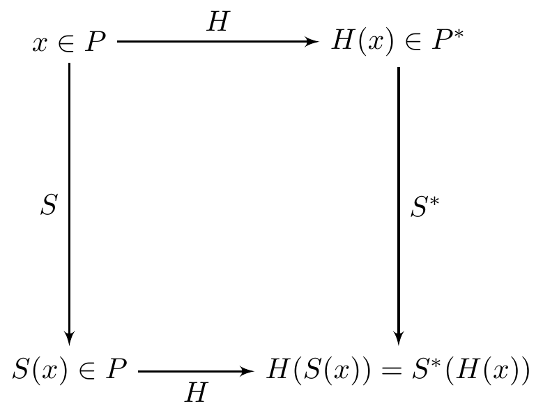

**Theorem** Any two peano systems are isomorphic

*Proof* Let $\mathscr{P} = (P, S, 1)$ and $\mathscr{P}^* = (P^*, S^*, 1^*)$ be two peano systems.

- Using the iteration theorem let $W = P^*$, $c = 1^*$, $g = S^*$ then there is a unique function, $F: P \longrightarrow P^*$ such that:
  - $F(1) = 1^*$
  - $F(S(x)) = S^*(F(x))$ for all $x \in P$
- Now we need to proof that $F$ is onto and one-one function
  - **Onto function**
    - Let $\mathscr{R}(F) = \{y: y \in P^* \land (\exists x)(x \in P \land F(x) = y) \}$
      - $\mathscr{R}(F) \subseteq P^*$
      - $1^* \in \mathscr{R}(F)$ because $1 \in P \land F(1) = 1^*$
      - Assume $y \in P^*$ then exists $x \in P$ such that $F(x) = y$
        - $\begin{split} S^*(y) & = S^*(F(x)) \\ & = F(S(x)) \end{split}$
          - Because $S(x) \in P \land F(S(x)) = S^*(y)$ then $S^*(y) \in \mathscr{R}(F)$
    - Therefore by the principle of mathematical induction $\mathscr{R}(F)=P^*$ so $F$ is an onto function
  - **One-one function**
    - Let $B = \{x: x \in P \land (\forall y)((y \in P \land x \neq y) \implies F(y) \neq F(x)) \}$
      - $B \subseteq P$ because if $x \in B$ then $x \in P$
      - Let $y \neq 1$ then $y = S(z)$.
        - $\begin{split} F(y) & = F(S(y)) \\ & = S^*(F(y)) \\ & \neq 1^* \\ & = F(1) \end{split}$
          - Therefore $y \neq 1 \implies F(y) \neq F(1)$
      - Assume $x \in B$
        - If $y = 1$ then $F(y) = 1^* \land y \neq S(x)$.
          - Furthermore $F(S(x)) = S^*(F(x)) \neq 1^* = F(1)$. Therefore $F(y) \neq F(S(x))$ so $S(x) \in B$
        - If $y \neq 1 \land y \neq S(x)$ then $(\exists z)(z \in P \land y = S(z))$ and $S(z) \neq S(x)$.
          - If $S$ is a function then $z \neq x$
            - $\begin{split} z \neq x \implies F(z) \neq F(x) \\ \implies S^*(F(z)) \neq S^*(F(x)) \implies F(S(z)) \neq F(S(x)) \\ \implies F(y) \neq F(S(x)) \end{split}$
              - Therefore $S(x) \in B$
    - Therefore by the principle of mathematical induction $B = P$ so $F$ is one-one function

**Remark 1** $F$ is unique so there is only one isomorphism between any two peano systems

**Remark 2** The isophormism $F$ between $\mathscr{P} = (P, S, 1)$ and $\mathscr{P}^* = (P^*, S^*, 1^*)$ preserves all defined operations and relations. For example, if $+, \times, <$ are the addition, multiplication and order in $\mathscr{P} = (P, S, 1)$ while $+^*, \times^*, <^*$ are the corresponding notions in $\mathscr{P}^* = (P^*, S^*, 1^*)$, then for any $x$ and $y$ in $P$:

- $F(x + y) = F(x) +^* F(1)$
  - Let $B = \{y: y \in P \land F(x + y) = F(x) +^* F(y) \text{ where } x \in P \}$
    - $B \subseteq P$ because if $y \in B$ then $y \in P$
    - $1 \in B$ because:
      - $\begin{split} F(x + 1) & = F(S(x)) \\ & = S^*(F(x)) \\ & = F(x) +^* 1^* \\ & = F(x) +^* F(1) \end{split}$
    - Assume $x \in B$
      - $\begin{split} F(x + S(y)) & = F(S(x + y)) \\ & = S^*(F(x + y)) \\ & = S^*(F(x) +^* F(y)) \\ & = F(x) +^* S^*(F(y)) \\ & = F(x) +^* F(S(y)) \end{split}$
        - Therefore $S(y) \in B$
  - Therefore by the principle of mathematical induction $B = P$
- $F(x \times y) = F(x) \times^* F(y)$
  - Let $B = \{y: y \in P \land F(x \times y) = F(x) \times^* F(y) \text{ where } x \in P \}$
    - $B \subseteq P$ because if $y \in B$ then $y \in P$
    - $1 \in B$ because:
      - $\begin{split} F(x \times S(y)) & = F(x) \\ & = F(x) \times^* 1^* \\ & = F(x) \times^* F(1) \end{split}$
    - Assume $x \in B$
      - $\begin{split} F(x \times S(y)) & = F(x + x \times y) \\ & = F(x) +^* F(x \times y) \\ & = F(x) +^* F(x) \times^* F(y) \\ & = F(x) \times 1^* +^* F(x) \times^* F(y) \\ & = F(x) \times^* (1^* +^* F(y)) \\ & = F(x) \times^* S^*(F(y)) \\ & = F(x) \times^* F(S(y)) \end{split}$
        - Therefore $S(y) \in B$
  - Therefore by the principle of mathematical induction $B = P$
- $x < y \iff F(x) <^* F(y)$
  - $\begin{split} x < y & \iff (\exists z)(z \in P \land x + z = y) \\ & \iff (\exists z)(z \in P \land F(x + z) = F(y)) \\ & \iff (\exists F(z))(F(z) \in P^* \land F(x) +^* F(z) = F(y)) \\ & \iff F(x) <^* F(y) \end{split}$

A set of axioms is said to be **categorical** if and only if any two models for those axioms are isomorphic. Thus axioms $P1$, $P2$ and $P3$ for peano systems are categorical

- The notion of peano system really has been onlt partially axiomatized by means of axioms $P1$, $P2$ and $P3$. The logical notions and the concept of set have been left informal
  - If we add logical and set-theorical axioms to axioms $P1$, $P2$ and $P3$ in such a way that all proofs are based upon explicitly stated axioms and rules of inference, then the enlarged axiom system is no longer categorical. Check out (Mendelson 2015, Section 2.11 & Chapter 3) for more details

## 1.13 A basic existence assumption

- Intuitive understanding of the natural numbers
  - Symbolic expressions
    - $1$ is $|$, $2$ is $||$, $3$ is $|||$, and so on
      - Different people and different civilizations may use different symbols for the basic unit. For example, a circel or a square instead of a stroke
      - Yet, we could not give priority to one symbolism over any others
      - We also have to admit that, regardless of the difference in symbols, we are all talking about the same things
- Set-theoric objects
  - $1 = \{ \emptyset \}$, $2 = \{ \emptyset, 1 \} = \{ \emptyset, \{ \emptyset \} \}$, $3 = \{ \emptyset , \{ \emptyset \}, \{ \emptyset \, \{ \emptyset \} \} \}$ and so on
  - $1 = \{ \emptyset \}$, $2 = \{ 1 \}$, $3 = \{ 2 \}$ and so on
  - Even in set theory, there is no single way to handle the natural numbers

Different people, different languages and different set theories may have different systems of natural numbers. However they all satisfy the axioms for peano systems and therefore are isomorphic.

- For peano systems, as for all the mathematical systems we shall encounter later, it is the structure which is important, not the content. Since the natural numbers are necessary in the further development of mathematics we shall make one simple assumption:
  - **Basic axiom** There exists a peano sytem
    - In Appendix E there is a proof of the **Basic axiom** within a system of axiomatic set theory. However, this is not a clear-cut justification for the **Basic axiom** as the discussion above has indicated

## 1.14 Supplementary exercises

1. By a Dedekind system we mean any structure $(P, S)$ where $P$ is a set, $S$ is a singulary operation on $P$ and the following axioms are satisfied:
- $(1')$ The range of $S$ is a proper susbset of $P$: $\mathscr{R}(S) \neq P$
- $(2')$ $S$ is one-one: $(\forall x)(\forall y)((x \in P \land y \in P \land x \neq y) \implies S(x) \neq S(y))$
- $(3')$ Principle of mathematical induction:
  $$(\forall z)(\forall B)((B \subseteq P \land z \in P - \mathscr{R}(S) \land z \in B \land (\forall x)(x \in B \implies S(x) \in B)) \implies B = P)$$
  - Prove that $(\exists !u)(u \in P - \mathscr{R}(S))$ (Hint: Let $z \in P - \mathscr{R}(S)$ and apply the principle of mathematical induction (Axiom $(3')$) to the set $B = \mathscr{R}(S) \cup \{ z \}$)
    - $B \subseteq P$ because $\mathscr{R}(S) \subseteq P \land \{ z \} \subseteq P$
    - If $x \in \mathscr{R}(S)$ then $x \notin P - \mathscr{R}(S)$ therefore there is only one element that belongs to $P - \mathscr{R}(S)$ which is $z$
      - $z \in P - \mathscr{R}(S)$
      - $z \in B = \mathscr{R}(S) \cup \{ z \}$
    - Assume $x \in B$ then $x \in \mathscr{R}(S) \lor x \in \{ z\}$
      - If $x \in \mathscr{R}(S)$ then exists $u$ such that $S(u) = x$. Because $\mathscr{R}(S) \subseteq P$ then $x \in P$. Thus, $S(S(u)) = S(x)$ so $S(x) \in \mathscr{R}(S)$ which implies $S(x) \in B = \mathscr{R}(S) \cup \{ z \}$
      - If $x \in \{ z\}$ then $x = z$. Also because $x \in P \land \mathscr{D}(S) = P$ then $S(z) \in \mathscr{R}(S)$. Thus $S(z) \in B = \mathscr{R}(S) \cup \{ z \}$
        - By Axiom $(3')$ we have that $B = P$ so $P - \mathscr{R}(S) = \{ z \}$ which implies there is exactly one element in $P - \mathscr{R}(S)$
  - Let the unique $u \in P - \mathscr{R}(S)$ be denoted $1$. Prove that $(P, S, 1)$ is a peano system
    - $1 \in P - \mathscr{R}(S)$ therefore $1 \notin \mathscr{R}(S)$. Thus, $(\forall x)(x \in P = B \implies S(x) \neq 1 = z)$
    - $(P,S)$ is a Dedekind system so by Axiom $(2')$ we have that $S$ is a one-one function. Therefore $(\forall x)(\forall y)(x \neq y \implies S(x) \neq S(y))$
    - $(P,S)$ is a Dedekind system, $z = 1$ and $z$ is unique so by Axiom $(2')$ we have that $(\forall B)((B \subseteq P \land 1 \in P - \mathscr{R}(S) \land 1 \in B \land (\forall x)(x \in B \implies S(x) \in B)) \implies B = P)$ which implies that:
      $$(\forall B)((B \subseteq P \land 1 \in B \land (\forall x)(x \in B \implies S(x) \in B)) \implies B = P)$$
      - Therefore $(P, S, 1)$ is a peano system
2. A second proof of the iteration theorem. Consider a set $W$, an element $c$ in $W$ and a singulary operation $g$ on $W$. Let $(P, S, 1)$ be a peano sytem. We must show that there is a unique function $F: P \longrightarrow W$ such that $F(1) = c$ and $F(S(x)) = g(F(x))$ for all $x \in P$.
- Let $\mathscr{C} = \{H: H \subseteq P \times W \land (1,c) \in H \land (\forall x)(\forall w)((x,w) \in H \implies (S(x), g(w)) \in H) \}$.
  - Observe that $P \times W \in \mathscr{C}$.
    - $P \times W \subseteq P \times W$
    - $(1, c) \in P \times W$
    - $(\forall x)(\forall w)((x,w) \in P \times W \implies (S(x), g(w)) \in P \times W)$ because $(x,w) \in P \times W$ is the set of all orderec pairs $(x, w)$ such that $x \in P \land w \in W$. We have that $S(x) \in P \land g(w) \in W$ then $(S(x), g(w)) \in P \times W$
  - Let $F = \bigcap_{H \in \mathscr{C}} H$. Observe that $F \neq \emptyset$ because $(\forall H)(H \in \mathscr{C} \implies (1,c) \in H)$ therefore $(1,c) \in F$
    - Prove that:
      - $F \in \mathscr{C}$
        - $F = \{(x,w): (\forall H)(H \in \mathscr{C} \implies (x,w) \in H)\}$. Therefore:
          - If $(x,w) \in F$ then $(x,w) \in P \times W$. Thus, $F \subseteq P \times W$
          - $(1,c) \in F$
          - If $(x,w) \in F$ then $(\forall H)(H \in \mathscr{C} \implies (x,w) \in H)$. Therefore $(\forall H)((H \in \mathscr{C} \implies (x,w) \in H) \implies (S(x), g(w)) \in H)$ which means that $(S(x),g(w)) \in F$
      - $F: P \longrightarrow W$ (Hint: Let $B = \{x: (\exists !w)(w \in W \land (x,w) \in F)\}$. By mathematical induction, prove $B = P$)
        - Let $B = \{x: x \in P \land (\exists !w)(w \in W \land (x,w) \in F)\}$
          - $B \subseteq P$ because if $x \in B$ then $x \in P$
          - Let $(1,c) \in H \land (1,w) \in H \land w \neq c$ where $H \in \mathscr{C}$. Let $H - \{(1,w): w \neq c\}$ then $H - \{(1,w): w \neq c\} \in \mathscr{C}$ so $(1,w) \notin F$ because $F = \{(x,w): (\forall H)(H \in \mathscr{C} \implies (x,w) \in H)\}$. Therefore $1 \in B$
          - Assume $x \in B$
            - $\begin{split} x \in B & \implies (\exists !w)(w \in W \land (x,w) \in F) \\ & \implies (\exists !w)((w \in W \land (x,w) \in F) \implies (S(w), g(w)) \in F)) \\ & \implies (\exists !w)((S(w), g(w)) \in F) \\ & \implies (\exists !w)((S(w), g(w)) \in F) \\ & \implies S(x) \in B \end{split}$
              - Therefore by the principle of mathematical induction $B=P$. Also because $\mathscr{D}(F) = P$ then $\mathscr{D}(F) = B$ which implies that $F$ is a function
      - $F(1) = c$
        - $(1, c) \in F$ and $F$ is a function so $F(1) = c$
      - $F(S(x)) = g(F(x))$ for all $x \in P$
        - $\begin{split} F \in \mathscr{C} & \implies (\forall x)(\forall w)((x,w) \in F \implies (S(x), g(w)) \in F) \\ & \implies (\forall x)(\forall w)(F(x)=w \implies F(S(x)) = g(w))) \\ & \implies (\forall x)(\forall w)(F(x)=w \implies F(S(x)) = g(F(x)))) & \implies (\forall x)(F(S(x)) = g(F(x)))) \end{split}$
          - **Observation** If there is a function $G: P \longrightarrow W$ such that $G(1) = c$ and $G(S(x)) = g(G(x))$ for all $x \in P$ then $\mathscr{D}(F) = P = \mathscr{D}(G)$ and $F(1) = c = G(1)$. Furthermore:
            - Let $B = \{x: x \in P \land F(x) = G(x) \}$
              - $B \subseteq P$ because if $x \in B$ then $x \in P$
              - $1 \in B$
              - Assume $x \in B$
                - $\begin{split} F(S(x)) & = g(F(x)) \\ & = g(G(x)) \\ & = G(S(x)) \end{split}$
                  - Therefore $S(x) \in B$
            - Therefore by the principle of mathematical induction $B=P$ which implies that $F(x) = G(x)$ for all $x \in P$.
          - Because $\mathscr{D}(F) = \mathscr{D}(G)$ and $F(x) = G(x)$ for all $x \in P$ we have that $F = G$ so $F$ is unique
3. Why is the following not a correct proof that any two peano systems $\mathscr{P} = (P, S, 1)$ and $\mathscr{P}^* = (P^*, S^*, 1^*)$ are isomorphic?
- $P$ consist of $1, S(1), S(S(1)), S(S(1)), S(S(S(1))), \ldots$
- $P^*$ consist of $1^*, S^*(1^*), S^*(S^*(1^*)), S^*(S^*(S^*(1^*))), \ldots$
- Simply let $1$ corresponds to $1^*$, $S(1)$ to $S^*(1^*)$, $S(S(1))$ to $S^*(S^*(1^*))$, $S(S(S(1)))$ to $S^*(S^*(S^*(1^*)))$ and so on such that each object in the list $P$ being associated with the corresponding object in the list for $P^*$
  - I think this sketch is not totally incorrect. The problem is that it doesn’t include all the details but the general idea seems right
    - It uses the implicitly the principle of mathematical induction to build both lists
    - It builds an implicit onto and one-one function:
      - $F(1) = 1^*$, $F(S(1)) = S^*(1^*)$, $F(S(S(1))) = S^*(S^*(1^*))$, $F(S(S(S(1)))) = S^*(S^*(S^*(1^*))), \ldots$
        - $F(1) = 1^*$, $F(S(1)) = S^*(F(1))$, $F(S(S(1))) = S^*(F(S(1)))$, $F(S(S(S(1)))) = S^*(F(S(S(1)))), \ldots$
          - Thus, it is using implicitly the defintion of isomorphism between $\mathscr{P}$ and $\mathscr{P}^*$
4. Prove that the relation “isomorphic with” is reflexive, symmetric and transitive, that is, for any peano systems $\mathscr{P} = (P, S, 1)$, $\mathscr{P}^* = (P^*, S^*, 1^*)$ and $\mathscr{P}^\# = (P^\#, S^\#, 1^\#)$:
   - $\mathscr{P}$ is isomorphic with $\mathscr{P}$ (Reflexivity)
     - Let $I_P: P \xrightarrow[\text{onto}]{\text{1-1}} P$ be the identity function in $P$ such that
       - $I_P(1) = 1$
       - $I_P(S(x)) = S(I_P(x))$ for all $x \in P$
         - Therefore $I_P$ is a isomorphism between $\mathscr{P}$ and $\mathscr{P}$
   - If $\mathscr{P}$ is isomorphic with $\mathscr{P}^*$ then $\mathscr{P}^*$ is isomorphic with $\mathscr{P}$ (Symmetry)
     - If $\mathscr{P}$ is isomorphic with $\mathscr{P}^*$ then there exists, $H: P \xrightarrow[\text{onto}]{\text{1-1}} P^*$ such that:
       - $H(1) = 1^*$
       - $H(S(x)) = S^*(H(x))$ for all $x \in P$
         - Therefore $H(x) = x^*$ where $x^* \in P^*$ so $x = H^{-1}(H(x)) = H^-1(x^*)$
           - Therefore $H^{-1}: P^* \xrightarrow[\text{onto}]{\text{1-1}} P$ such that:
             - $H^{-1}(1^*) = H^{-1}(H(1)) = 1$
             - $\begin{split} H{-1}(S^*(x^*)) & = H^{-1}(S^*(H(x))) \\ & = H^{-1}(H(S(x))) \\ & = S(x) \\ & = S(H^-1(x^*)) \end{split}$
               - Therefore $H^{-1}$ is a isomorphism between $\mathscr{P}^*$ and $\mathscr{P}$
   - If $\mathscr{P}$ is isomorphic with $\mathscr{P}^*$ and $\mathscr{P}^*$ is isomorphic with $\mathscr{P}^\#$ then $\mathscr{P}$ is isomorphic with $\mathscr{P}^\#$ (Transitivity)
     - There exists, $H: P \xrightarrow[\text{onto}]{\text{1-1}} P^*$ and $G: P^* \xrightarrow[\text{onto}]{\text{1-1}} P^\#$ such that:
       - $H(1) = 1^* \land G(1^*) = 1^\#$
       - $H(S(x)) = S^*(H(x))$ for all $x \in P$ and $G(S^*(x^*)) = S^\#(G(x^*))$ for all $x^* \in P^*$
         - Let $G \circ H: P \xrightarrow[\text{onto}]{\text{1-1}} P^\#$ such that:
           - $(G \circ H)(1) = G(H(1)) = G(1^*) = 1^\#$
             - $\begin{split} (G \circ H)(S(x)) & = G(H(S(x)) \\ & = G(S^*(H(x))) \\ & = S^\#(G(H(x))) \\ & = S^\#((G \circ H)(x)) \\ \end{split}$
               - Therefore $G \circ H$ is a isomorphism between $\mathscr{P}$ and $\mathscr{P}^\#$
5. Consider a structure $(P, S, 1)$ where $1 \in P$ and $S: P \longrightarrow P$. Show that $(P, S, 1)$ is a peano system if and only if satisfies the iteration theorem, that is, for any set $W$, any object $c \in W$ and any singulary operation $g$ on $W$, there is a unique function $F: P \longrightarrow W$ such that $F(1) = c$ and $F(S(x)) = g(F(x))$ for all $x \in P$
   - Assume a structure $(P, S, 1)$ where $1 \in P$ and $S: P \longrightarrow P$ is a peano system
     - Using *Chapter 2 > Supplementary exercises > Exercise 2* if $(P, S, 1)$ is a peano system then it satisfies the iteration theorem
   - Assume a structure $(P, S, 1)$ where $1 \in P$, $S: P \longrightarrow P$ and there is a unique function $F: P \longrightarrow W$ such that $F(1) = c$ and $F(S(x)) = g(F(x))$ for all $x \in P$ where $W$ is any set, $c \in W$ and $g$ is any singulary operation on $W$ [Checkout (Saunders and Birkhoff 1967, Chapter 2, Section 11, p. 67-70), (Lawvere 2005) or (Bedoya Mejía 2003)]
     - We need to prove that $(\forall x)(x \in P \implies S(x) \neq 1)$
       - Assume there is some $p \in P$ such that $S(p) = 1$. Let $W = \{ y,z \}$ where $y \neq z$, $c = y \in W$ and $g(y) = g(z) = z$. Also let $F: P \longrightarrow \{ y,z \}$ such that:
         - $F(1) = y$
         - $F(S(x)) = g(F(x))$ for all $x \in P$
           - Also $F(1) = F(S(p)) = g(F(p)) = z$. Therefore $y = F(1) = z$ but $y \neq z$ which is a contradiction.
             - Thus, $(\exists p)(p \in P \land S(p) = 1)$ is false so $(\forall p)\neg(p \in P \land S(p) = 1)$ is true which is equivalent to $(\forall p)(p \in P \implies S(p)$
     - We need to prove that $(\forall x)(\forall y)((x \in P \land y \in P \land x \neq y) \implies S(x) \neq S(y))$. Thus, we must prove that $S$ is one-one, $S: P \xrightarrow[]{\text{1-1}} P$
       - First prove that if $f: P \longrightarrow P$ such that $f(1) = 1$ and $f(S(n)) = S(f(n))$ for all $n \in P$ then $f = I_p$
         - Let $W = P$, $c = 1 \in W$ and $g = S$ then by the iteration theorem there is a unique function $f: P \longrightarrow P$ such that:
           - $f(1) = 1$
           - $f(S(n)) = S(f(n))$ for all $n \in P$
         - We have also that
           - $I_p(1) = 1$
           - $I_p(S(n)) = S(n) = S(I_p(n))$ for all $n \in P$
         - Because $f$ is unique we have that $f = I_p$
       - Second, let $W = P \times P$, $c = (1,1) \in W$ and $g((q, p)) = (p, S(p))$. Therefore there is a unique function $F: P \longrightarrow P \times P$ such that:
         - $F(1) = (1, 1)$
         - $F(S(x)) = g(F(x))$ for all $x \in P$
           - Because $F: P \longrightarrow P \times P$ then $F(x) = (t(x), f(x))$ for all $x \in P$ such that $t: P \longrightarrow P$ and $f: P \longrightarrow P$. Therefore:
             - $\begin{split} F(S(x)) & = (t(S(x)), f(S(x))) \\ & = g(F(x)) \\ & = g(t(x), f(x)) \\ & = (f(x), S(f(x))) \end{split}$
               - Thus, $t(S(x)) = f(x)$ for all $x \in P$ and $f(S(x)) = $S(f(x))$ for all $x \in P$. Also
                 - Because $f(1) = 1$ and $f(S(x)) = S(f(x))$ then $f = I_p$
                 - $t(1) = 1$ and $t(S(x)) = f(x) = x$
                   - Now with this result we can prove that $S$ is one-one:
                     - $\begin{split} S(x) = S(y) & \implies t(S(x)) = t(S(y)) \\ & \implies x = y \end{split}$
     - We need to prove that $(\forall B)((B \subseteq P \land 1 \in B \land (\forall x)(x \in B \implies S(x) \in B)) \implies P = B)$
       - Because $B \subseteq P$ and $S: P \longrightarrow P$ we can define the restriction of the operation $S$ to $B$ denoted by $g$ such that:
         - $\mathscr{D}(g) = B$
         - $g(u) = S(u)$ for all $u \in B$
           - Let $W = B$, $c = 1 \in W$ and $g$ the restriction of the operation $S$ to $B$. Therefore there is a unique function $F: P \longrightarrow B$ such that:
             - $F(1) = 1$
             - $F(S(x)) = g(F(x))$ for all $x \in P$
           - Because $B \subseteq P$ let a function $h: B \longrightarrow P$ such that $h(u) = u$ for all $u \in B$ then:
             - $h(1) = 1$
             - $h(g(u)) = h(S(u)) = S(u) = S(h(u))$ for all $u \in B$
               - First, we have that $h(g(u)) = S(h(u))$ for all $u \in B$
               - Second, we have that $h \circ F: P \longrightarrow P$:
                 - $h(F(1)) = F(1) = 1$
                 - $h(F(S(x))) = h(g(F(x))) = S(h(F(x)))$ for all $x \in P$
                   - Thus, we have that:
                     - $(h \circ F)(1) = 1$
                     - $(h \circ F)(S(x)) = S((h \circ F)(x))$ for all $x \in P$
                       - So $h \circ F = I_P$
                         - We can use this result to prove that $h$ is an onto function:
                           - $\mathscr{R}(h) = \{y: \exists(z)(z \in B \land y = h(x))$
                           - Thus, we need to show that $\mathscr{R}(h) = N$. Let $w \in P$ then $w \in \mathscr{R}(h)$ because exists $F(w) \in B$ such that $w = h(F(w))$ so $h$ is an onto function.
                             - Because $h: B \longrightarrow P$ such that $h(u) = u$ for all $u \in B$ and $h$ is an onto function then $B = P$
6. Show that each of axioms $P1$, $P2$ and $P3$ is independent of the other axioms. (For example, to show the independence of axiom $P1$, give an example of a structure $(P, S, 1)$ which satisfies axioms $P2$ and $P3$ but does not satisfy axiom $P1$)
   - Let a structure $(P, S, 1)$ such that:
     - $P = \{1, 2\}$
     - $S(1) = 2, S(2) = 1$
       - $S(1) = 2$
       - $1 \neq 2 \land S(2) = 1 \neq 2 = S(1)$
       - The subsets of $P$ are $\mathscr{P} = \{ \emptyset, \{ 1 \}, \{ 2 \}, \{ 1,2 \} \}$ where:
         - $1 \notin \emptyset$ and $1 \notin \{ 2 \}$
         - $1 \in \{ 1,2 \}$, $1 \in \{ 1,2 \} \land S(1) = 2 \in \{ 1,2 \}$ and $2 \in \{ 1,2 \} \land S(2) = 1 \in \{ 1,2 \}$. Furthermore $\{ 1,2 \} = P$
           - Thus, $(P, S, 1)$ satisfies axioms $P2$ and $P3$ but not $P1$
   - Let a structure $(P, S, 1)$ such that:
     - $P = \{1, 2, 3\}$
     - $S(1) = 2, S(2) = 3, S(3) = 2$
       - $S(1) \neq 1, S(2) \neq 1, S(3) \neq 1$
       - $1 \neq 3 \land S(1) = 2 = S(3)$
       - The subsets of $P$ are $\mathscr{P} = \{ \emptyset, \{ 1 \}, \{ 2 \}, \{ 3 \}, \{ 1,2 \}, \{ 2,3 \}, \{ 1,3 \}, \{ 1, 2, 3 \} \}$ where:
         - $1 \notin \emptyset$, $1 \notin \{ 2 \}$, $1 \notin \{ 3 \}$, $1 \notin \{ 2,3 \}$, $1 \in \{ 1 \} \land S(1) = 2 \notin \{ 1 \}$, $1 \in \{ 1,2 \} \land S(2) = 3 \notin \{ 1,2 \}$, $1 \in \{ 1,3 \} \land S(1) = 2 \notin \{ 1,3 \}$ and $1 \in \{ 1,2,3 \} \land S(1) = 2 \in \{ 1,2,3 \}$, $2 \in \{ 1,2,3 \} \land S(2) = 3 \in \{ 1,2,3 \}$, $3 \in \{ 1,2,3 \} \land S(3) = 2 \in \{ 1,2,3 \}$. Furthermore, $\{ 1,2,3 \} = P$
           - Thus, $(P,S,1)$ satisfies axioms $P1$ and $P3$ but not $P2$
   - Let a structure $(P, S, 1)$ such that:
     - $P = \{1, 2, 3, \ldots \}$
     - Let $S: P \longrightarrow P$ such that:
       - $S(1) = 3$
       - $S(2) = 2$
       - $S(x) = x + 1$ for all $x \geq 3 \land x \in P$
     - $P - \{ 2 \} \subseteq P$, $1 \in P - \{ 2 \}$ and $(\forall x)(x \in P - \{ 2 \} \implies S(x) \in P - \{ 2 \})$. However $P - \{ 2 \} \neq P$
       - Thus, $(P,S,1)$ satisfies axioms $P1$ and $P2$ but not $P3$
7. Let $(P, S, 1)$ be a peano system, $Y$ be any set, $d \in Y$ and $h: P \times Y \longrightarrow Y$.
   - Prove that there is a unique function $\Phi: P \longrightarrow Y$ such that $\Phi(1) = d$ and $\Phi(S(n)) = h(n, \Phi(n))$ for all $n \in P$
     - First prove that if $f: P \longrightarrow P$ such that $f(1) = 1$ and $f(S(n)) = S(f(n))$ for all $n \in P$ then $f = I_p$
       - Let $W = P$, $c = 1 \in W$ and $g = S$ then by the iteration theorem there is a unique function $f: P \longrightarrow P$ such that:
         - $f(1) = 1$
         - $f(S(n)) = S(f(n))$ for all $n \in P$
       - We have also that
         - $I_p(1) = 1$
         - $I_p(S(n)) = S(n) = S(I_p(n))$ for all $n \in P$
       - Because $f$ is unique we have that $f = I_p$
     - Second, let $W = P \times Y$, $c = (1, d) \in W$ and $g: P \times Y \longrightarrow P \times Y$ such that $g((n, y)) = (S(n), h(n,y))$ therefore by the iteration theorem there is a unique $F: P \longrightarrow P \times Y$ such that:
       - $F(1) = (1,d)$
       - $F(S(n)) = g(F(n))$ for all $n \in P$
         - Because $F: P \longrightarrow P \times Y$ then $F(n) = (f(n), \Phi(n))$ for all $n \in P$ such that $f: P \longrightarrow P$ and $\Phi: P \longrightarrow Y$. Therefore:
           - $\begin{split} F(S(n)) & = (f(S(n)), \Phi(S(n))) \\ & = g(F(n)) \\ & = g(f(n), \Phi(n)) \\ & = (S(f(n)), h(n,\Phi(n))) \end{split}$
             - Thus, $f(S(n)) = S(f(n))$ for all $n \in P$ and $\Phi(S(n)) = h(n,\Phi(n))$ for all $n \in P$. Also
               - Because $f(1) = 1$ and $f(S(n)) = S(f(n))$ for all $n \in P$ then $f = I_p$
               - $\Phi(1) = d$ and $\Phi(n + 1) = h(n,\Phi(n))$
                 - Furthermore, if there is another $\Phi^*: P \longrightarrow Y$ such that $\Phi^*(1) = d$ and $\Phi^*(n + 1) = h(n,\Phi^*(n))$ then $F(n) = (n, \Phi^*(n))$. Also because $F(n) = (n, \Phi(n))$ we have that:
                   - $(n, \Phi^*(n)) = (n, \Phi(n)) \implies \Phi^*(n) = \Phi(n)$ for all $n \in P$
                     - Also because $\mathscr{D}(\Phi^*) = P = \mathscr{D}(\Phi)$ then $\Phi^* = \Phi$ so $\Phi$ is unique
   - Show that there is a **factorial** function $n!$ from $P$ into $P$ such that $1! = 1$ and $(n + 1)! = (n + 1) \times (n!)$ for all $n \in P$
     - There exist a unique function $\Phi: P \longrightarrow P$ such that:
       - $\Phi(1) = 1$
       - $\Phi(S(n)) = h(n, \Phi(n))$ for all $n \in P$ where $h: P \times P \longrightarrow P$
         - Let $\Phi = !$ and $!(x) \equiv x!$. Also let $h(u, \Phi(u)) \equiv h(u, u!) = S(u) \times (u!)$ then we can rewrite the above expressions as:
           - $1! = 1$
           - $(n + 1)! = (n + 1) \times (n!)$ for all $n \in P$

## 1.15 Suggestions for further reading

- (Wang 1957) is an excellent historical review on the contributions to the foundations of artihmetic made by:
  - Hermann Günther Grassmann (1809 – 1877): publication of **Lehrbuch der Arithmetik** (1861)
  - Julius Wilhelm Richard Dedekind (1831 - 1916): letter written by Dedekind explaining how he arrive at the peano axioms and publication of **Was sind und was sollen die Zahlen?** (1888)
  - Friedrich Ludwig Gottlob Frege (1848 – 1925): publication of **Begriffsschrift** (1879) and **Die Grundlagen der Arithmetik** (1884)
  - Giuseppe Peano (1858 - 1932): borrowed his axioms from Dedekind and made extensive use of Grassmann’s work in his development of the axioms
- (Heijenoort 2002) is and excellent source to find english translations of:
  - **Begriffsschrift** (1879) by Friedrich Ludwig Gottlob Frege (1848 – 1925)
  - **Arithmetices principia, nova methodo exposita** (1889) by Giuseppe Peano (1858 - 1932)
  - **Letter to Keferstein** (1890) by Julius Wilhelm Richard Dedekind (1831 - 1916) which is the letter pointed out in (Wang 1957)

# Bibliography

Bedoya Mejía, Lina María. 2003. “Peano, Lawvere, Peirce: Tres Axiomatizaciones de Los Números Naturales.”

Heijenoort, Jean van. 2002. *From Frege to Godel: A Source Book in Mathematical Logic, 1879-1931*. 4th ed. Cambridge, Massachusetts: Harvard University Press.

Lawvere, Francis William. 2005. “An Elementary Theory of the Category of Sets (Long Version) with Commentary.” *Reprints in Theory and Applications of Categories*, no. 11: 1–35. http://www.tac.mta.ca/tac/reprints/articles/11/tr11.pdf.

Mendelson, Elliott. 2008. *Number Systems and the Foundations of Analysis*. Mineola, N.Y: Dover Publications.

———. 2015. *Introduction to Mathematical Logic*. Sixth edition. Textbooks in Mathematics. Boca Raton: CRC Press/Taylor & Francis Group.

Saunders, MacLane, and Garrett Birkhoff. 1967. *Algebra*. 1st ed. New York, Macmillan. https://archive.org/details/algebra00macl/mode/2up.

Wang, Hao. 1957. “The Axiomatization of Arithmetic.” *Journal of Symbolic Logic* 22 (2): 145–58. https://doi.org/10.2307/2964176.